# CIND820_PROJECTCODE

```python
print("prelim stats")
```

```
prelim stats
```

```python
#import libraries

import csv
import pandas as pd
import numpy as np
```

```python
#import and read csv file
#display first 10 rows

import pandas as pd
crime_data1 = pd.read_csv(r"C:\Users\radon\Documents\CIND820/crimedata.csv")

crime_data1.head(10)
```

|  | communityname | state | countyCode | communityCode | fold | population | householdsize | racepctblack | racePctWhite | racePctAsian | racePctHisp | agePct12t21 | agePct12t29 | agePct16t24 | agePct65up | numbUrban | pctUrban | medIncome | pctWWage | pctWFarmSelf | pctWInvInc | pctWSocSec | pctWPubAsst | pctWRetire | medFamInc | perCapInc | whitePerCap | blackPerCap | indianPerCap | … |
| --- | --- | --- | --- | --- | --- | --- | --- | --- | --- | --- | --- | --- | --- | --- | --- | --- | --- | --- | --- | --- | --- | --- | --- | --- | --- | --- | --- | --- | --- | --- |
| 0 | BerkeleyHeightstownship | NJ | 39 | 5320 | 1 | 11980 | 3.10 | 1.37 | 91.78 | 6.50 | 1.88 | 12.47 | 21.44 | 10.93 | 11.33 | 11980 | 100.0 | 75122 | 89.24 | 1.55 | 70.20 | 23.62 | 1.03 | 18.39 | 79584 | 29711 | 30233 | 13600 | 5725 | … |
| 1 | Marpletownship | PA | 45 | 47616 | 1 | 23123 | 2.82 | 0.80 | 95.57 | 3.44 | 0.85 | 11.01 | 21.30 | 10.48 | 17.18 | 23123 | 100.0 | 47917 | 78.99 | 1.11 | 64.11 | 35.50 | 2.75 | 22.85 | 55323 | 20148 | 20191 | 18137 | 0 | … |
| 2 | Tigardcity | OR | ? | ? | 1 | 29344 | 2.43 | 0.74 | 94.33 | 3.43 | 2.35 | 11.36 | 25.88 | 11.01 | 10.28 | 29344 | 100.0 | 35669 | 82.00 | 1.15 | 55.73 | 22.25 | 2.94 | 14.56 | 42112 | 16946 | 17103 | 16644 | 21606 | … |
| 3 | Gloversvillecity | NY | 35 | 29443 | 1 | 16656 | 2.40 | 1.70 | 97.35 | 0.50 | 0.70 | 12.55 | 25.20 | 12.19 | 17.57 | 0 | 0.0 | 20580 | 68.15 | 0.24 | 38.95 | 39.48 | 11.71 | 18.33 | 26501 | 10810 | 10909 | 9984 | 4941 | … |
| 4 | Bemidjicity | MN | 7 | 5068 | 1 | 11245 | 2.76 | 0.53 | 89.16 | 1.17 | 0.52 | 24.46 | 40.53 | 28.69 | 12.65 | 0 | 0.0 | 17390 | 69.33 | 0.55 | 42.82 | 32.16 | 11.21 | 14.43 | 24018 | 8483 | 9009 | 887 | 4425 | … |
| 5 | Springfieldcity | MO | ? | ? | 1 | 140494 | 2.45 | 2.51 | 95.65 | 0.90 | 0.95 | 18.09 | 32.89 | 20.04 | 13.26 | 140494 | 100.0 | 21577 | 75.78 | 1.00 | 41.15 | 29.31 | 7.12 | 14.09 | 27705 | 11878 | 12029 | 7382 | 10264 | … |
| 6 | Norwoodtown | MA | 21 | 50250 | 1 | 28700 | 2.60 | 1.60 | 96.57 | 1.47 | 1.10 | 11.17 | 27.41 | 12.76 | 14.42 | 28700 | 100.0 | 42805 | 79.47 | 0.39 | 47.70 | 30.23 | 5.41 | 17.23 | 50394 | 18193 | 18276 | 17342 | 21482 | … |
| 7 | Andersoncity | IN | ? | ? | 1 | 59459 | 2.45 | 14.20 | 84.87 | 0.40 | 0.63 | 15.31 | 27.93 | 14.78 | 14.60 | 59449 | 100.0 | 23221 | 71.60 | 0.67 | 35.74 | 32.58 | 8.81 | 22.59 | 28901 | 12161 | 12599 | 9820 | 6634 | … |
| 8 | Fargocity | ND | 17 | 25700 | 1 | 74111 | 2.46 | 0.35 | 97.11 | 1.25 | 0.73 | 16.64 | 35.16 | 20.33 | 8.58 | 74115 | 100.0 | 25326 | 83.69 | 2.93 | 47.11 | 19.30 | 4.21 | 10.31 | 34269 | 13554 | 13727 | 8852 | 5344 | … |
| 9 | Wacocity | TX | ? | ? | 1 | 103590 | 2.62 | 23.14 | 67.60 | 0.92 | 16.35 | 19.88 | 34.55 | 21.62 | 13.12 | 103590 | 100.0 | 17852 | 74.20 | 0.86 | 30.98 | 29.09 | 9.06 | 13.99 | 24058 | 10195 | 12126 | 5715 | 11313 | … |

```python
#display data types of all columns

datatypes = crime_data1.dtypes
print(datatypes)
```

```
communityname             object
state                     object
countyCode                object
communityCode             object
fold                       int64
population                 int64
householdsize            float64
racepctblack             float64
racePctWhite             float64
racePctAsian             float64
 racePctHisp             float64
agePct12t21              float64
agePct12t29              float64
agePct16t24              float64
 agePct65up              float64
numbUrban                  int64
 pctUrban                float64
 medIncome                 int64
pctWWage                 float64
pctWFarmSelf             float64
pctWInvInc               float64
pctWSocSec               float64
 pctWPubAsst             float64
pctWRetire               float64
medFamInc                  int64
 perCapInc                 int64
whitePerCap                int64
blackPerCap                int64
indianPerCap               int64
AsianPerCap                int64
OtherPerCap               object
HispPerCap                 int64
NumUnderPov                int64
PctPopUnderPov           float64
PctLess9thGrade          float64
PctNotHSGrad             float64
PctBSorMore              float64
PctUnemployed            float64
PctEmploy                float64
PctEmplManu              float64
```

[output cut: 93 more lines]

```
robberies                 object
robbbPerPop               object
assaults                  object
assaultPerPop             object
burglaries                object
burglPerPop               object
larcenies                 object
larcPerPop                object
autoTheft                 object
autoTheftPerPop           object
arsons                    object
arsonsPerPop              object
ViolentCrimesPerPop       object
nonViolPerPop             object
dtype: object
```

```python
#replace all missing values with NaN

import pandas as pd
crime_data = pd.read_csv('crimedata.csv', na_values=['?'])
crime_data.head(10)
```

|  | communityname | state | countyCode | communityCode | fold | population | householdsize | racepctblack | racePctWhite | racePctAsian | racePctHisp | agePct12t21 | agePct12t29 | agePct16t24 | agePct65up | numbUrban | pctUrban | medIncome | pctWWage | pctWFarmSelf | pctWInvInc | pctWSocSec | pctWPubAsst | pctWRetire | medFamInc | perCapInc | whitePerCap | blackPerCap | indianPerCap | … |
| --- | --- | --- | --- | --- | --- | --- | --- | --- | --- | --- | --- | --- | --- | --- | --- | --- | --- | --- | --- | --- | --- | --- | --- | --- | --- | --- | --- | --- | --- | --- |
| 0 | BerkeleyHeightstownship | NJ | 39.0 | 5320.0 | 1 | 11980 | 3.10 | 1.37 | 91.78 | 6.50 | 1.88 | 12.47 | 21.44 | 10.93 | 11.33 | 11980 | 100.0 | 75122 | 89.24 | 1.55 | 70.20 | 23.62 | 1.03 | 18.39 | 79584 | 29711 | 30233 | 13600 | 5725 | … |
| 1 | Marpletownship | PA | 45.0 | 47616.0 | 1 | 23123 | 2.82 | 0.80 | 95.57 | 3.44 | 0.85 | 11.01 | 21.30 | 10.48 | 17.18 | 23123 | 100.0 | 47917 | 78.99 | 1.11 | 64.11 | 35.50 | 2.75 | 22.85 | 55323 | 20148 | 20191 | 18137 | 0 | … |
| 2 | Tigardcity | OR | NaN | NaN | 1 | 29344 | 2.43 | 0.74 | 94.33 | 3.43 | 2.35 | 11.36 | 25.88 | 11.01 | 10.28 | 29344 | 100.0 | 35669 | 82.00 | 1.15 | 55.73 | 22.25 | 2.94 | 14.56 | 42112 | 16946 | 17103 | 16644 | 21606 | … |
| 3 | Gloversvillecity | NY | 35.0 | 29443.0 | 1 | 16656 | 2.40 | 1.70 | 97.35 | 0.50 | 0.70 | 12.55 | 25.20 | 12.19 | 17.57 | 0 | 0.0 | 20580 | 68.15 | 0.24 | 38.95 | 39.48 | 11.71 | 18.33 | 26501 | 10810 | 10909 | 9984 | 4941 | … |
| 4 | Bemidjicity | MN | 7.0 | 5068.0 | 1 | 11245 | 2.76 | 0.53 | 89.16 | 1.17 | 0.52 | 24.46 | 40.53 | 28.69 | 12.65 | 0 | 0.0 | 17390 | 69.33 | 0.55 | 42.82 | 32.16 | 11.21 | 14.43 | 24018 | 8483 | 9009 | 887 | 4425 | … |
| 5 | Springfieldcity | MO | NaN | NaN | 1 | 140494 | 2.45 | 2.51 | 95.65 | 0.90 | 0.95 | 18.09 | 32.89 | 20.04 | 13.26 | 140494 | 100.0 | 21577 | 75.78 | 1.00 | 41.15 | 29.31 | 7.12 | 14.09 | 27705 | 11878 | 12029 | 7382 | 10264 | … |
| 6 | Norwoodtown | MA | 21.0 | 50250.0 | 1 | 28700 | 2.60 | 1.60 | 96.57 | 1.47 | 1.10 | 11.17 | 27.41 | 12.76 | 14.42 | 28700 | 100.0 | 42805 | 79.47 | 0.39 | 47.70 | 30.23 | 5.41 | 17.23 | 50394 | 18193 | 18276 | 17342 | 21482 | … |
| 7 | Andersoncity | IN | NaN | NaN | 1 | 59459 | 2.45 | 14.20 | 84.87 | 0.40 | 0.63 | 15.31 | 27.93 | 14.78 | 14.60 | 59449 | 100.0 | 23221 | 71.60 | 0.67 | 35.74 | 32.58 | 8.81 | 22.59 | 28901 | 12161 | 12599 | 9820 | 6634 | … |
| 8 | Fargocity | ND | 17.0 | 25700.0 | 1 | 74111 | 2.46 | 0.35 | 97.11 | 1.25 | 0.73 | 16.64 | 35.16 | 20.33 | 8.58 | 74115 | 100.0 | 25326 | 83.69 | 2.93 | 47.11 | 19.30 | 4.21 | 10.31 | 34269 | 13554 | 13727 | 8852 | 5344 | … |
| 9 | Wacocity | TX | NaN | NaN | 1 | 103590 | 2.62 | 23.14 | 67.60 | 0.92 | 16.35 | 19.88 | 34.55 | 21.62 | 13.12 | 103590 | 100.0 | 17852 | 74.20 | 0.86 | 30.98 | 29.09 | 9.06 | 13.99 | 24058 | 10195 | 12126 | 5715 | 11313 | … |

```python
#check number of rows
len(crime_data)
```

```
2215
```

```python
#check datatypes again

datatypes2 = crime_data.dtypes
print(datatypes2)
```

```
communityname             object
state                     object
countyCode               float64
communityCode            float64
fold                       int64
population                 int64
householdsize            float64
racepctblack             float64
racePctWhite             float64
racePctAsian             float64
 racePctHisp             float64
agePct12t21              float64
agePct12t29              float64
agePct16t24              float64
 agePct65up              float64
numbUrban                  int64
 pctUrban                float64
 medIncome                 int64
pctWWage                 float64
pctWFarmSelf             float64
pctWInvInc               float64
pctWSocSec               float64
 pctWPubAsst             float64
pctWRetire               float64
medFamInc                  int64
 perCapInc                 int64
whitePerCap                int64
blackPerCap                int64
indianPerCap               int64
AsianPerCap                int64
OtherPerCap              float64
HispPerCap                 int64
NumUnderPov                int64
PctPopUnderPov           float64
PctLess9thGrade          float64
PctNotHSGrad             float64
PctBSorMore              float64
PctUnemployed            float64
PctEmploy                float64
PctEmplManu              float64
```

[output cut: 93 more lines]

```
robberies                float64
robbbPerPop              float64
assaults                 float64
assaultPerPop            float64
burglaries               float64
burglPerPop              float64
larcenies                float64
larcPerPop               float64
autoTheft                float64
autoTheftPerPop          float64
arsons                   float64
arsonsPerPop             float64
ViolentCrimesPerPop      float64
nonViolPerPop            float64
dtype: object
```

```python
#display the sum of all NaN in each column

crime_data.isnull().sum()
```

```python
#seperate all columns with missing values

null_cols = crime_data[crime_data.columns[crime_data.isna().any()]]
null_cols.head()
```

|  | countyCode | communityCode | OtherPerCap | LemasSwornFT | LemasSwFTPerPop | LemasSwFTFieldOps | LemasSwFTFieldPerPop | LemasTotalReq | LemasTotReqPerPop | PolicReqPerOffic | PolicPerPop | RacialMatchCommPol | PctPolicWhite | PctPolicBlack | PctPolicHisp | PctPolicAsian | PctPolicMinor | OfficAssgnDrugUnits | NumKindsDrugsSeiz | PolicAveOTWorked | PolicCars | PolicOperBudg | LemasPctPolicOnPatr | LemasGangUnitDeploy | PolicBudgPerPop | rapes | rapesPerPop | robberies | robbbPerPop | … |
| --- | --- | --- | --- | --- | --- | --- | --- | --- | --- | --- | --- | --- | --- | --- | --- | --- | --- | --- | --- | --- | --- | --- | --- | --- | --- | --- | --- | --- | --- | --- |
| 0 | 39.0 | 5320.0 | 5115.0 | NaN | NaN | NaN | NaN | NaN | NaN | NaN | NaN | NaN | NaN | NaN | NaN | NaN | NaN | NaN | NaN | NaN | NaN | NaN | NaN | NaN | NaN | 0.0 | 0.00 | 1.0 | 8.20 | … |
| 1 | 45.0 | 47616.0 | 5250.0 | NaN | NaN | NaN | NaN | NaN | NaN | NaN | NaN | NaN | NaN | NaN | NaN | NaN | NaN | NaN | NaN | NaN | NaN | NaN | NaN | NaN | NaN | 1.0 | 4.25 | 5.0 | 21.26 | … |
| 2 | NaN | NaN | 5954.0 | NaN | NaN | NaN | NaN | NaN | NaN | NaN | NaN | NaN | NaN | NaN | NaN | NaN | NaN | NaN | NaN | NaN | NaN | NaN | NaN | NaN | NaN | 6.0 | 16.60 | 56.0 | 154.95 | … |
| 3 | 35.0 | 29443.0 | 2451.0 | NaN | NaN | NaN | NaN | NaN | NaN | NaN | NaN | NaN | NaN | NaN | NaN | NaN | NaN | NaN | NaN | NaN | NaN | NaN | NaN | NaN | NaN | 10.0 | 57.86 | 10.0 | 57.86 | … |
| 4 | 7.0 | 5068.0 | 3000.0 | NaN | NaN | NaN | NaN | NaN | NaN | NaN | NaN | NaN | NaN | NaN | NaN | NaN | NaN | NaN | NaN | NaN | NaN | NaN | NaN | NaN | NaN | NaN | NaN | 4.0 | 32.04 | … |

```python
#display sums of missing values of only columns that contain missing values

null_list= null_cols.columns.values
null_cols.isnull().sum()
```

```
countyCode              1221
communityCode           1224
OtherPerCap                1
LemasSwornFT            1872
LemasSwFTPerPop         1872
LemasSwFTFieldOps       1872
LemasSwFTFieldPerPop    1872
LemasTotalReq           1872
LemasTotReqPerPop       1872
PolicReqPerOffic        1872
PolicPerPop             1872
RacialMatchCommPol      1872
PctPolicWhite           1872
PctPolicBlack           1872
PctPolicHisp            1872
PctPolicAsian           1872
PctPolicMinor           1872
OfficAssgnDrugUnits     1872
NumKindsDrugsSeiz       1872
PolicAveOTWorked        1872
PolicCars               1872
PolicOperBudg           1872
LemasPctPolicOnPatr     1872
LemasGangUnitDeploy     1872
PolicBudgPerPop         1872
rapes                    208
rapesPerPop              208
robberies                  1
robbbPerPop                1
assaults                  13
assaultPerPop             13
burglaries                 3
burglPerPop                3
larcenies                  3
larcPerPop                 3
autoTheft                  3
autoTheftPerPop            3
arsons                    91
arsonsPerPop              91
ViolentCrimesPerPop      221
nonViolPerPop             97
dtype: int64
```

```python
#change settings to display all columns
pd.set_option('display.max_columns', None)

#get summary statistics of all columns
crime_data.describe()
```

|  | countyCode | communityCode | fold | population | householdsize | racepctblack | racePctWhite | racePctAsian | racePctHisp | agePct12t21 | agePct12t29 | agePct16t24 | agePct65up | numbUrban | pctUrban | medIncome | pctWWage | pctWFarmSelf | pctWInvInc | pctWSocSec | pctWPubAsst | pctWRetire | medFamInc | perCapInc | whitePerCap | blackPerCap | indianPerCap | AsianPerCap | OtherPerCap | … |
| --- | --- | --- | --- | --- | --- | --- | --- | --- | --- | --- | --- | --- | --- | --- | --- | --- | --- | --- | --- | --- | --- | --- | --- | --- | --- | --- | --- | --- | --- | --- |
| count | 994.000000 | 991.000000 | 2215.000000 | 2.215000e+03 | 2215.000000 | 2215.000000 | 2215.000000 | 2215.000000 | 2215.000000 | 2215.000000 | 2215.000000 | 2215.000000 | 2215.000000 | 2.215000e+03 | 2215.000000 | 2215.000000 | 2215.000000 | 2215.000000 | 2215.000000 | 2215.000000 | 2215.000000 | 2215.000000 | 2215.000000 | 2215.000000 | 2215.000000 | 2215.000000 | 2215.000000 | 2215.000000 | 2214.000000 | … |
| mean | 65.587525 | 45209.251261 | 5.494357 | 5.311798e+04 | 2.707327 | 9.335102 | 83.979819 | 2.670203 | 7.950176 | 14.445837 | 27.644840 | 13.975142 | 11.836393 | 4.773472e+04 | 70.465309 | 33984.696163 | 78.312758 | 0.881842 | 43.750935 | 26.409418 | 6.801445 | 15.969002 | 39857.055079 | 15603.524605 | 16567.698420 | 11541.749436 | 12229.191422 | 14227.989616 | 9442.765131 | … |
| std | 117.831399 | 25425.861573 | 2.872924 | 2.046203e+05 | 0.334120 | 14.247156 | 16.419080 | 4.473843 | 14.589832 | 4.518623 | 6.181517 | 5.970747 | 4.777565 | 2.056067e+05 | 44.080275 | 13424.680011 | 7.950672 | 0.689006 | 12.787925 | 8.295604 | 4.700335 | 4.622553 | 14251.206032 | 6281.558523 | 6346.840251 | 9232.102062 | 14853.836177 | 9881.266395 | 7926.466713 | … |
| min | 1.000000 | 70.000000 | 1.000000 | 1.000500e+04 | 1.600000 | 0.000000 | 2.680000 | 0.030000 | 0.120000 | 4.580000 | 9.380000 | 4.640000 | 1.660000 | 0.000000e+00 | 0.000000 | 8866.000000 | 31.680000 | 0.000000 | 5.810000 | 4.810000 | 0.180000 | 3.460000 | 10447.000000 | 5237.000000 | 5472.000000 | 0.000000 | 0.000000 | 0.000000 | 0.000000 | … |
| 25% | 11.000000 | 22887.000000 | 3.000000 | 1.436600e+04 | 2.500000 | 0.860000 | 76.320000 | 0.620000 | 0.930000 | 12.250000 | 24.415000 | 11.320000 | 8.750000 | 0.000000e+00 | 0.000000 | 23817.000000 | 73.400000 | 0.460000 | 34.680000 | 20.770000 | 3.270000 | 12.875000 | 29538.000000 | 11602.500000 | 12610.500000 | 6742.500000 | 6345.000000 | 8285.500000 | 5528.250000 | … |
| 50% | 27.000000 | 46925.000000 | 5.000000 | 2.279200e+04 | 2.660000 | 2.870000 | 90.350000 | 1.230000 | 2.180000 | 13.620000 | 26.780000 | 12.540000 | 11.730000 | 1.804100e+04 | 100.000000 | 31441.000000 | 78.610000 | 0.690000 | 42.880000 | 26.590000 | 5.610000 | 15.650000 | 36678.000000 | 14101.000000 | 15073.000000 | 9777.000000 | 9895.000000 | 12250.000000 | 8186.000000 | … |
| 75% | 80.500000 | 65805.000000 | 8.000000 | 4.302400e+04 | 2.850000 | 11.145000 | 96.225000 | 2.670000 | 7.810000 | 15.360000 | 29.205000 | 14.345000 | 14.415000 | 4.191800e+04 | 100.000000 | 41480.500000 | 84.030000 | 1.100000 | 52.740000 | 31.715000 | 9.105000 | 18.755000 | 46999.000000 | 17795.000000 | 18609.500000 | 14526.000000 | 14757.500000 | 17327.500000 | 11525.500000 | … |
| max | 840.000000 | 94597.000000 | 10.000000 | 7.322564e+06 | 5.280000 | 96.670000 | 99.630000 | 57.460000 | 95.290000 | 54.400000 | 70.510000 | 63.620000 | 52.770000 | 7.322564e+06 | 100.000000 | 123625.000000 | 96.760000 | 6.530000 | 89.040000 | 76.390000 | 44.820000 | 45.510000 | 139008.000000 | 63302.000000 | 68850.000000 | 212120.000000 | 480000.000000 | 106165.000000 | 137000.000000 | … |

```python
crime_data.info()
```

```
<class 'pandas.core.frame.DataFrame'>
RangeIndex: 2215 entries, 0 to 2214
Columns: 147 entries, communityname to nonViolPerPop
dtypes: float64(116), int64(29), object(2)
memory usage: 2.5+ MB
```

```python
#find the mean of each column by state
mean_data = crime_data.groupby("state").mean()
mean_data.head()
```

| state | countyCode | communityCode | fold | population | householdsize | racepctblack | racePctWhite | racePctAsian | racePctHisp | agePct12t21 | agePct12t29 | agePct16t24 | agePct65up | numbUrban | pctUrban | medIncome | pctWWage | pctWFarmSelf | pctWInvInc | pctWSocSec | pctWPubAsst | pctWRetire | medFamInc | perCapInc | whitePerCap | blackPerCap | indianPerCap | AsianPerCap | OtherPerCap | … |
| --- | --- | --- | --- | --- | --- | --- | --- | --- | --- | --- | --- | --- | --- | --- | --- | --- | --- | --- | --- | --- | --- | --- | --- | --- | --- | --- | --- | --- | --- | --- |
| AK | NaN | NaN | 7.333333 | 94644.000000 | 2.756667 | 6.826667 | 77.906667 | 4.136667 | 4.086667 | 13.986667 | 29.586667 | 13.966667 | 4.303333 | 73915.000000 | 32.656667 | 41301.000000 | 89.586667 | 1.083333 | 74.923333 | 10.960000 | 6.843333 | 13.766667 | 46051.333333 | 18068.333333 | 19928.333333 | 12596.666667 | 10115.333333 | 12005.333333 | 12153.000000 | … |
| AL | NaN | NaN | 6.000000 | 39231.186047 | 2.611860 | 27.044651 | 71.799535 | 0.750000 | 0.665116 | 16.117209 | 28.540233 | 15.227209 | 12.415581 | 34182.069767 | 64.992558 | 26034.860465 | 75.144419 | 0.855814 | 33.825349 | 28.445814 | 8.100930 | 15.898837 | 33033.232558 | 13065.651163 | 14933.186047 | 7357.930233 | 12009.325581 | 12114.069767 | 6510.232558 | … |
| AR | NaN | NaN | 5.440000 | 32674.520000 | 2.652800 | 19.470000 | 78.883600 | 0.835600 | 0.979200 | 16.207600 | 29.028800 | 15.354400 | 12.666400 | 20450.480000 | 40.000000 | 22025.560000 | 73.618400 | 1.258000 | 32.592800 | 29.241200 | 8.465200 | 14.075200 | 27477.320000 | 11245.760000 | 12798.640000 | 7215.760000 | 8606.000000 | 10218.360000 | 9461.120000 | … |
| AZ | NaN | NaN | 5.700000 | 125811.650000 | 2.778500 | 2.610500 | 84.655500 | 1.574500 | 22.434500 | 14.850000 | 27.722500 | 13.808500 | 11.690500 | 114430.000000 | 54.660000 | 32264.500000 | 77.323000 | 0.952000 | 38.545500 | 25.294000 | 6.444000 | 16.827500 | 37024.700000 | 15380.050000 | 16208.950000 | 14505.700000 | 10459.250000 | 12970.100000 | 7450.900000 | … |
| CA | 76.0 | 93325.0 | 5.591398 | 79654.179211 | 2.926129 | 5.312222 | 71.973799 | 9.480896 | 24.799427 | 13.974158 | 28.252581 | 13.678136 | 9.780287 | 76204.000000 | 85.266989 | 39655.982079 | 80.120394 | 0.827849 | 40.754624 | 21.825520 | 8.877240 | 14.881900 | 44720.125448 | 17465.885305 | 18957.817204 | 13960.465950 | 14410.684588 | 15125.035842 | 10407.967742 | … |

```python
#find the mean of crime per pop columns by state
state_crimes =crime_data.groupby("state")["murdPerPop", "rapesPerPop", "robbbPerPop", "assaultPerPop", "burglPerPop", "larcPerPop", "autoTheftPerPop", "arsonsPerPop"].mean()
state_crimes.head(10)
```

| state | murdPerPop | rapesPerPop | robbbPerPop | assaultPerPop | burglPerPop | larcPerPop | autoTheftPerPop | arsonsPerPop |
| --- | --- | --- | --- | --- | --- | --- | --- | --- |
| AK | 8.870000 | 66.080000 | 156.103333 | 345.516667 | 639.463333 | 3813.090000 | 485.286667 | 23.833333 |
| AL | 11.342093 | 42.825349 | 199.333721 | 777.197674 | 1273.725814 | 3730.038605 | 399.103953 | 35.178750 |
| AR | 10.735600 | 52.083600 | 195.645600 | 460.085200 | 1450.826400 | 4575.336800 | 450.897200 | 32.514800 |
| AZ | 4.613500 | 30.195000 | 119.256000 | 397.030000 | 1510.476500 | 4325.365000 | 661.164500 | 35.179000 |
| CA | 8.134588 | 32.646882 | 273.137276 | 496.704964 | 1248.996595 | 3022.680896 | 819.774265 | 47.988530 |
| CO | 3.822800 | 41.320400 | 84.554000 | 397.163600 | 965.632800 | 4010.375600 | 350.701200 | 42.820400 |
| CT | 3.841972 | 16.033239 | 111.564366 | 127.755217 | 740.837746 | 2372.257465 | 425.045070 | 19.466338 |
| DC | 81.950000 | 58.480000 | 1282.850000 | 1625.090000 | 2081.590000 | 5679.780000 | 1454.870000 | 36.100000 |
| DE | 0.000000 | 123.330000 | 267.210000 | 496.750000 | 859.880000 | 6118.530000 | 260.360000 | 37.680000 |
| FL | 7.305556 | 49.775889 | 359.934778 | 742.029556 | 1932.676667 | 5190.722333 | 866.247889 | 21.462111 |

```python
#find the states with min and max mean values for crimes
state_crimes["murdPerPop"].sort_values()
state_crimes["rapesPerPop"].sort_values()
state_crimes["robbbPerPop"].sort_values()
state_crimes["assaultPerPop"].sort_values()
state_crimes["burglPerPop"].sort_values()
state_crimes["larcPerPop"].sort_values()
state_crimes["autoTheftPerPop"].sort_values()
state_crimes["arsonsPerPop"].sort_values()
```

```python
#find representation of each state in dataset, how many rows does each state have?
crime_data.groupby(['state'])['state'].count()
```

* MODULE 3: INITIAL CODE AND RESULTS

```python
#az = crime_data.loc[crime_data['state'] == "CA"]
#az.boxplot(column="murdPerPop")

#dc = crime_data.loc[crime_data['state']== "DC"]
```

Previously, we have discovered a number of missing values in the dataset. The number of values missing in each column varies. At this point, there are missing number values which are significant and cannot be used in the analysis. These columns will have to be dropped. I have decided on a NaN threshold of 50% (0.5), so any columns which are missing 50% of its values or more will be dropped from the dataset.

```python
#after deciding on a NaN ratio threshold, drop the columns which exceed the threshold (50%)

crimedata_reduced= crime_data.drop(['countyCode', 'communityCode', 'fold', 'LemasSwornFT', 'LemasSwFTPerPop', 'LemasSwFTFieldOps', 'LemasSwFTFieldPerPop', 'LemasTotalReq', 'LemasTotReqPerPop', 'PolicReqPerOffic', 'PolicPerPop', 'RacialMatchCommPol', 'PctPolicWhite', 'PctPolicBlack', 'PctPolicHisp', 'PctPolicAsian', 'PctPolicMinor', 'OfficAssgnDrugUnits', 'NumKindsDrugsSeiz', 'PolicAveOTWorked', 'PolicCars', 'PolicOperBudg', 'LemasPctPolicOnPatr', 'LemasGangUnitDeploy', 'PolicBudgPerPop'], axis=1)
crimedata_reduced.head()
```

|  | communityname | state | population | householdsize | racepctblack | racePctWhite | racePctAsian | racePctHisp | agePct12t21 | agePct12t29 | agePct16t24 | agePct65up | numbUrban | pctUrban | medIncome | pctWWage | pctWFarmSelf | pctWInvInc | pctWSocSec | pctWPubAsst | pctWRetire | medFamInc | perCapInc | whitePerCap | blackPerCap | indianPerCap | AsianPerCap | OtherPerCap | HispPerCap | … |
| --- | --- | --- | --- | --- | --- | --- | --- | --- | --- | --- | --- | --- | --- | --- | --- | --- | --- | --- | --- | --- | --- | --- | --- | --- | --- | --- | --- | --- | --- | --- |
| 0 | BerkeleyHeightstownship | NJ | 11980 | 3.10 | 1.37 | 91.78 | 6.50 | 1.88 | 12.47 | 21.44 | 10.93 | 11.33 | 11980 | 100.0 | 75122 | 89.24 | 1.55 | 70.20 | 23.62 | 1.03 | 18.39 | 79584 | 29711 | 30233 | 13600 | 5725 | 27101 | 5115.0 | 22838 | … |
| 1 | Marpletownship | PA | 23123 | 2.82 | 0.80 | 95.57 | 3.44 | 0.85 | 11.01 | 21.30 | 10.48 | 17.18 | 23123 | 100.0 | 47917 | 78.99 | 1.11 | 64.11 | 35.50 | 2.75 | 22.85 | 55323 | 20148 | 20191 | 18137 | 0 | 20074 | 5250.0 | 12222 | … |
| 2 | Tigardcity | OR | 29344 | 2.43 | 0.74 | 94.33 | 3.43 | 2.35 | 11.36 | 25.88 | 11.01 | 10.28 | 29344 | 100.0 | 35669 | 82.00 | 1.15 | 55.73 | 22.25 | 2.94 | 14.56 | 42112 | 16946 | 17103 | 16644 | 21606 | 15528 | 5954.0 | 8405 | … |
| 3 | Gloversvillecity | NY | 16656 | 2.40 | 1.70 | 97.35 | 0.50 | 0.70 | 12.55 | 25.20 | 12.19 | 17.57 | 0 | 0.0 | 20580 | 68.15 | 0.24 | 38.95 | 39.48 | 11.71 | 18.33 | 26501 | 10810 | 10909 | 9984 | 4941 | 3541 | 2451.0 | 4391 | … |
| 4 | Bemidjicity | MN | 11245 | 2.76 | 0.53 | 89.16 | 1.17 | 0.52 | 24.46 | 40.53 | 28.69 | 12.65 | 0 | 0.0 | 17390 | 69.33 | 0.55 | 42.82 | 32.16 | 11.21 | 14.43 | 24018 | 8483 | 9009 | 887 | 4425 | 3352 | 3000.0 | 1328 | … |

First, I will decide on my target/dependent variables. The two I have chosen are MURDERS and ROBBERIES. Many of my potential dependent variables are missing values, and are not able to be imputed as it may introduce bias. For this reason, I have chosen these 2 categories as my dependent variables because they have the LEAST amount of missing values. Now that my dependent variables are chosen, I can move on to dealing with my independent variables.

There are still a number of columns that remain with missing values. The number of NaNs, however, were below the threshold of 0.5 so they will be used in the analysis. To deal with these missing values, we will turn to imputation. For the columns of our independent variables with 1-15 total missing values, I have chosen to impute them with the overall mode of the column. Because the distribution of the columns is skewed, I have chosen to impute with the mode value per each individual column.

However, there are still a number of columns with a significant number of missing values, but fall below the threshold. These will have to be dealt with differently. For these values, I have chosen to aggregate the data first, and then choose my imputation method. The nature of the organization of the crimes is by neighbourhood, which are each found in a state. I thought aggregrating by state was the most logical choice, as we may find more geographical, social, and economic similarties overall (but not entirely) within each state and its population. Because there are a different number of neighbourhoods represented for each state, the representation is unbalanced. Because of this, I thought the most appropriate imputation method would be to impute these missing values with the mean by state, per each column.

```python
#impute missing values
#for columns with very small number of missing values, impute with MODE

crimedata_reduced['burglaries'].fillna(crimedata_reduced['burglaries'].mode()[0], inplace=True)
crimedata_reduced['burglPerPop'].fillna(crimedata_reduced['burglPerPop'].mode()[0], inplace=True)
crimedata_reduced['larcenies'].fillna(crimedata_reduced['larcenies'].mode()[0], inplace=True)
crimedata_reduced['larcPerPop'].fillna(crimedata_reduced['larcPerPop'].mode()[0], inplace=True)
crimedata_reduced['autoTheft'].fillna(crimedata_reduced['autoTheft'].mode()[0], inplace=True)
crimedata_reduced['autoTheftPerPop'].fillna(crimedata_reduced['autoTheftPerPop'].mode()[0], inplace=True)
crimedata_reduced['OtherPerCap'].fillna(crimedata_reduced['OtherPerCap'].mode()[0], inplace=True)
crimedata_reduced['assaults'].fillna(crimedata_reduced['assaults'].mode()[0], inplace=True)
crimedata_reduced['assaultPerPop'].fillna(crimedata_reduced['assaultPerPop'].mode()[0], inplace=True)
```

```python
#Find out the total counts of how many times each state is represented in the dataset
#With this information, I have chosen to impute by the mean value of the column, aggregated by state

#crimedata_reduced[crimedata_reduced['rapes'].isnull()]
#crimedata_reduced.pivot_table(index = ['state'], aggfunc ='size')

from collections import Counter
print(Counter(crimedata_reduced['state']))
```

```
Counter({'CA': 279, 'NJ': 211, 'TX': 162, 'MA': 123, 'OH': 111, 'MI': 108, 'PA': 101, 'FL': 90, 'CT': 71, 'MN': 66, 'WI': 60, 'IN': 48, 'NY': 46, 'NC': 46, 'AL': 43, 'MO': 42, 'WA': 40, 'IL': 40, 'GA': 37, 'OK': 36, 'TN': 35, 'VA': 33, 'OR': 31, 'SC': 28, 'KY': 26, 'RI': 26, 'AR': 25, 'CO': 25, 'UT'…
```

At this point, I will go through each state, and aggregate them one by one into their own, new data frames. For each seperate state dataframe, I will check for missing values. Rather than checking for the total number, I want the column names of where these missing values are located. I will then confirm the total length/number of rows in the dataset, and then check the total number of missing values in each column to get an idea of how much information is missing in each column per state. If the ratio is not significant, I will then move forward and impute the missing values as discussed previously, and then confirm if there are still any columns left with missing values.

Once confirmed that there are no longer any columns missing values, I will have to put these values back into the main dataset. I have filtered out the main dataset by state, so I will create a new dataframe titled crimedata_new. This new dataframe will include all the data, EXCEPT the data of the particular state I was working with. I will then append the seperate state dataframe to crimedata_new, replacing the old data of the state in which values were missing. Once again, I will confirm that all missing values were imputed as planned, by checking the count of missing values of crimedata_new, indexed by the particular state.

STATE: CA

```python
#Separate all rows represented by the state CA, and create a dataframe with them
CA = crimedata_reduced[crimedata_reduced['state']=='CA']
CA_df= pd.DataFrame(CA)

#Check for missing values: return names of each column that carries a missing value
CA_df.columns[CA_df.isna().any()]

#Check the total number of rows represented by the particular state
len(CA_df)

#Check total number of missing values in that column to establish the ratio of missing information that exists here
CA_df['ViolentCrimesPerPop'].isna().sum()

#If the ratio of missing information is not significant, impute the missing values with the mean of that column of its own state
CA_df['ViolentCrimesPerPop'].fillna(CA_df['ViolentCrimesPerPop'].mean(), inplace = True)

#Confirm values were successfully imputed
CA_df.columns[CA_df.isna().any()]
```

```
Index([], dtype='object')
```

```python
#Create a dataframe where we filter out all rows represented by the particular state
ca_filtered = crimedata_reduced[crimedata_reduced['state'] != 'CA']

#Create a new dataframe which will serve as our main, fully imputed dataframe
#In this new dataframe, take the filtered dataframe and append the imputed state dataframe to it
crimedata_new = pd.concat([ca_filtered, CA_df], ignore_index=True)

#Confirm there are no missing values in the rows of the particular state in the new main dataframe
Counter(crimedata_new[crimedata_new['state'] == "CA"].isna().any())
```

```
Counter({False: 122})
```

I will repeat the previous steps with every single state represented. If no columns are returned with missing values, I will move onto the next state.

STATE: NJ

```python
NJ = crimedata_reduced[crimedata_reduced['state']=='NJ']
NJ_df= pd.DataFrame(NJ)
NJ_df.columns[NJ_df.isna().any()]
```

```
Index([], dtype='object')
```

STATE: TX

```python
TX = crimedata_reduced[crimedata_reduced['state']=='TX']
TX_df= pd.DataFrame(TX)
TX_df.columns[TX_df.isna().any()]

len(TX_df)
TX_df['rapes'].isna().sum()
TX_df['rapesPerPop'].isna().sum()
TX_df['arsons'].isna().sum()
TX_df['arsonsPerPop'].isna().sum()
TX_df['ViolentCrimesPerPop'].isna().sum()
TX_df['nonViolPerPop'].isna().sum()
```

```
5
```

```python
TX_df['rapes'].fillna(TX_df['rapes'].mean(), inplace = True)
TX_df['rapesPerPop'].fillna(TX_df['rapesPerPop'].mean(), inplace = True)
TX_df['arsons'].fillna(TX_df['arsons'].mean(), inplace = True)
TX_df['arsonsPerPop'].fillna(TX_df['arsonsPerPop'].mean(), inplace = True)
TX_df['ViolentCrimesPerPop'].fillna(TX_df['ViolentCrimesPerPop'].mean(), inplace = True)
TX_df['nonViolPerPop'].fillna(TX_df['nonViolPerPop'].mean(), inplace = True)

TX_df.columns[TX_df.isna().any()]

tx_filtered = crimedata_reduced[crimedata_reduced['state'] != 'TX']
crimedata_new = pd.concat([tx_filtered, TX_df], ignore_index=True)

Counter(crimedata_new[crimedata_new['state'] == "TX"].isna().any())
```

[output not shown]

STATE: MA

```python
MA = crimedata_reduced[crimedata_reduced['state']=='MA']
MA_df= pd.DataFrame(MA)
MA_df.columns[MA_df.isna().any()]

len(MA_df)
MA_df['arsons'].isna().sum()
MA_df['arsonsPerPop'].isna().sum()
MA_df['ViolentCrimesPerPop'].isna().sum()
MA_df['nonViolPerPop'].isna().sum()
```

```
7
```

```python
MA_df['arsons'].fillna(MA_df['arsons'].mean(), inplace = True)
MA_df['arsonsPerPop'].fillna(MA_df['arsonsPerPop'].mean(), inplace = True)
MA_df['ViolentCrimesPerPop'].fillna(MA_df['ViolentCrimesPerPop'].mean(), inplace = True)
MA_df['nonViolPerPop'].fillna(MA_df['nonViolPerPop'].mean(), inplace = True)

MA_df.columns[MA_df.isna().any()]

ma_filtered = crimedata_reduced[crimedata_reduced['state'] != 'MA']
crimedata_new = pd.concat([ma_filtered, MA_df], ignore_index=True)

Counter(crimedata_new[crimedata_new['state'] == "MA"].isna().any())
```

```
Counter({False: 122})
```

STATE: OH

```python
OH = crimedata_reduced[crimedata_reduced['state']=='OH']
OH_df= pd.DataFrame(OH)
OH_df.columns[OH_df.isna().any()]

len(OH_df)
OH_df['arsons'].isna().sum()
OH_df['arsonsPerPop'].isna().sum()
OH_df['ViolentCrimesPerPop'].isna().sum()
OH_df['nonViolPerPop'].isna().sum()
```

```
3
```

```python
OH_df['arsons'].fillna(OH_df['arsons'].mean(), inplace = True)
OH_df['arsonsPerPop'].fillna(OH_df['arsonsPerPop'].mean(), inplace = True)
OH_df['ViolentCrimesPerPop'].fillna(OH_df['ViolentCrimesPerPop'].mean(), inplace = True)
OH_df['nonViolPerPop'].fillna(OH_df['nonViolPerPop'].mean(), inplace = True)

OH_df.columns[OH_df.isna().any()]

oh_filtered = crimedata_reduced[crimedata_reduced['state'] != 'OH']
crimedata_new = pd.concat([oh_filtered, OH_df], ignore_index=True)

Counter(crimedata_new[crimedata_new['state'] == "OH"].isna().any())
```

```
Counter({False: 122})
```

***For the state MI, I have run into a problem. Out of the 6 columns which include missing values, 3 of the columns are able to be imputed, as they are not missing a significant amount of values. However the other 3 are missing ALL values in the entire column. This particular state is represented by 108 rows. The columns, rapes, rapesPerPop and ViolentCrimesPerPop are missing all 108 values.

STATE: MI

```python
MI = crimedata_reduced[crimedata_reduced['state']=='MI']
MI_df= pd.DataFrame(MI)
MI_df.columns[MI_df.isna().any()]

len(MI_df)

#TOTAL rows for MI was 108
#The three columns beneath are missing ALL 108 values in these columns, there are no values to work with in order to impute the mean
MI_df['ViolentCrimesPerPop'].isna().sum()
MI_df['rapes'].isna().sum()
MI_df['rapesPerPop'].isna().sum()

#The following rows are not missing an insignificant amount of values, they can be imputed as planned
MI_df['arsons'].isna().sum()
MI_df['arsonsPerPop'].isna().sum()
MI_df['nonViolPerPop'].isna().sum()
```

```
1
```

```python
#Impute the columns that are appropriate to be imputed by the mean

MI_df['arsons'].fillna(MI_df['arsons'].mean(), inplace = True)
MI_df['arsonsPerPop'].fillna(MI_df['arsonsPerPop'].mean(), inplace = True)
MI_df['nonViolPerPop'].fillna(MI_df['nonViolPerPop'].mean(), inplace = True)

MI_df.columns[MI_df.isna().any()]

mi_filtered = crimedata_reduced[crimedata_reduced['state'] != 'MI']
crimedata_new = pd.concat([mi_filtered, MI_df], ignore_index=True)

Counter(crimedata_new[crimedata_new['state'] == "MI"].isna().any())
MI_df.columns[MI_df.isna().any()]

#There are still 3 columns that have not been addressed
#These columns must be revisited
```

```
Index(['rapes', 'rapesPerPop', 'ViolentCrimesPerPop'], dtype='object')
```

STATE: PA

```python
PA = crimedata_reduced[crimedata_reduced['state']=='PA']
PA_df= pd.DataFrame(PA)
PA_df.columns[PA_df.isna().any()]

len(PA_df)
PA_df['arsons'].isna().sum()
PA_df['arsonsPerPop'].isna().sum()
PA_df['nonViolPerPop'].isna().sum()
```

```
1
```

```python
PA_df['arsons'].fillna(PA_df['arsons'].mean(), inplace = True)
PA_df['arsonsPerPop'].fillna(PA_df['arsonsPerPop'].mean(), inplace = True)
PA_df['nonViolPerPop'].fillna(PA_df['nonViolPerPop'].mean(), inplace = True)

PA_df.columns[PA_df.isna().any()]

pa_filtered = crimedata_reduced[crimedata_reduced['state'] != 'PA']
crimedata_new = pd.concat([pa_filtered, PA_df], ignore_index=True)

Counter(crimedata_new[crimedata_new['state'] == "PA"].isna().any())
```

```
Counter({False: 122})
```

STATE: FL

```python
FL = crimedata_reduced[crimedata_reduced['state']=='FL']
FL_df= pd.DataFrame(FL)
FL_df.columns[FL_df.isna().any()]
```

```
Index([], dtype='object')
```

STATE: CT

```python
CT = crimedata_reduced[crimedata_reduced['state']=='CT']
CT_df= pd.DataFrame(CT)
CT_df.columns[CT_df.isna().any()]

len(CT_df)
CT_df['ViolentCrimesPerPop'].isna().sum()
```

```
2
```

```python
CT_df['ViolentCrimesPerPop'].fillna(CT_df['ViolentCrimesPerPop'].mean(), inplace = True)

CT_df.columns[CT_df.isna().any()]

ct_filtered = crimedata_reduced[crimedata_reduced['state'] != 'CT']
crimedata_new = pd.concat([ct_filtered, CT_df], ignore_index=True)

Counter(crimedata_new[crimedata_new['state'] == "CT"].isna().any())
```

```
Counter({False: 122})
```

STATE: MN

```python
MN = crimedata_reduced[crimedata_reduced['state']=='MN']
MN_df= pd.DataFrame(MN)
MN_df.columns[CA_df.isna().any()]
```

```
Index([], dtype='object')
```

STATE: WI

```python
WI = crimedata_reduced[crimedata_reduced['state']=='WI']
WI_df= pd.DataFrame(WI)
WI_df.columns[WI_df.isna().any()]

len(WI_df)
WI_df['arsons'].isna().sum()
WI_df['arsonsPerPop'].isna().sum()
WI_df['nonViolPerPop'].isna().sum()
```

```
1
```

```python
WI_df['arsons'].fillna(WI_df['arsons'].mean(), inplace = True)
WI_df['arsonsPerPop'].fillna(WI_df['arsonsPerPop'].mean(), inplace = True)
WI_df['nonViolPerPop'].fillna(WI_df['nonViolPerPop'].mean(), inplace = True)

WI_df.columns[WI_df.isna().any()]

wi_filtered = crimedata_reduced[crimedata_reduced['state'] != 'WI']
crimedata_new = pd.concat([wi_filtered, WI_df], ignore_index=True)

Counter(crimedata_new[crimedata_new['state'] == "WI"].isna().any())
```

```
Counter({False: 122})
```

STATE: IN

```python
IN = crimedata_reduced[crimedata_reduced['state']=='IN']
IN_df= pd.DataFrame(IN)
IN_df.columns[IN_df.isna().any()]
```

```
Index([], dtype='object')
```

STATE: NY

```python
NY = crimedata_reduced[crimedata_reduced['state']=='NY']
NY_df= pd.DataFrame(NY)
NY_df.columns[NY_df.isna().any()]

len(NY_df)
NY_df['arsons'].isna().sum()
NY_df['arsonsPerPop'].isna().sum()
NY_df['nonViolPerPop'].isna().sum()
```

```
17
```

```python
NY_df['arsons'].fillna(NY_df['arsons'].mean(), inplace = True)
NY_df['arsonsPerPop'].fillna(NY_df['arsonsPerPop'].mean(), inplace = True)
NY_df['nonViolPerPop'].fillna(NY_df['nonViolPerPop'].mean(), inplace = True)

NY_df.columns[NY_df.isna().any()]

ny_filtered = crimedata_reduced[crimedata_reduced['state'] != 'NY']
crimedata_new = pd.concat([ny_filtered, NY_df], ignore_index=True)

Counter(crimedata_new[crimedata_new['state'] == "NY"].isna().any())
```

```
Counter({False: 122})
```

STATE: NC

```python
NC = crimedata_reduced[crimedata_reduced['state']=='NC']
NC_df= pd.DataFrame(NC)
NC_df.columns[NC_df.isna().any()]
```

```
Index([], dtype='object')
```

STATE: AL

```python
AL = crimedata_reduced[crimedata_reduced['state']=='AL']
AL_df= pd.DataFrame(AL)
AL_df.columns[AL_df.isna().any()]

len(AL_df)
AL_df['arsons'].isna().sum()
AL_df['arsonsPerPop'].isna().sum()
AL_df['nonViolPerPop'].isna().sum()

len(AL_df)
```

```
43
```

```python
AL_df['arsons'].fillna(AL_df['arsons'].mean(), inplace = True)
AL_df['arsonsPerPop'].fillna(AL_df['arsonsPerPop'].mean(), inplace = True)
AL_df['nonViolPerPop'].fillna(AL_df['nonViolPerPop'].mean(), inplace = True)

AL_df.columns[AL_df.isna().any()]

al_filtered = crimedata_reduced[crimedata_reduced['state'] != 'AL']
crimedata_new = pd.concat([al_filtered, AL_df], ignore_index=True)

Counter(crimedata_new[crimedata_new['state'] == "AL"].isna().any())
```

```
Counter({False: 122})
```

STATE: MO

```python
MO = crimedata_reduced[crimedata_reduced['state']=='MO']
MO_df= pd.DataFrame(MO)
MO_df.columns[MO_df.isna().any()]
```

```
Index([], dtype='object')
```

STATE: WA

```python
WA = crimedata_reduced[crimedata_reduced['state']=='WA']
WA_df= pd.DataFrame(WA)
WA_df.columns[WA_df.isna().any()]

len(WA_df)
WA_df['arsons'].isna().sum()
WA_df['arsonsPerPop'].isna().sum()
WA_df['nonViolPerPop'].isna().sum()
```

```
1
```

```python
WA_df['arsons'].fillna(WA_df['arsons'].mean(), inplace = True)
WA_df['arsonsPerPop'].fillna(WA_df['arsonsPerPop'].mean(), inplace = True)
WA_df['nonViolPerPop'].fillna(WA_df['nonViolPerPop'].mean(), inplace = True)

WA_df.columns[WA_df.isna().any()]

wa_filtered = crimedata_reduced[crimedata_reduced['state'] != 'WA']
crimedata_new = pd.concat([wa_filtered, WA_df], ignore_index=True)

Counter(crimedata_new[crimedata_new['state'] == "WA"].isna().any())
```

```
Counter({False: 122})
```

STATE: IL **MISSING VALUES 1.0: All columns which are missing values are missing 100% of its values

```python
IL = crimedata_reduced[crimedata_reduced['state']=='IL']
IL_df= pd.DataFrame(IL)
IL_df.columns[IL_df.isna().any()]

len(IL_df)
IL_df['rapes'].isna().sum()
IL_df['rapesPerPop'].isna().sum()
IL_df['ViolentCrimesPerPop'].isna().sum()
```

```
40
```

STATE: GA

```python
GA = crimedata_reduced[crimedata_reduced['state']=='GA']
GA_df= pd.DataFrame(GA)
GA_df.columns[GA_df.isna().any()]
```

```
Index([], dtype='object')
```

STATE: OK

```python
OK = crimedata_reduced[crimedata_reduced['state']=='OK']
OK_df= pd.DataFrame(OK)
OK_df.columns[OK_df.isna().any()]
```

```
Index([], dtype='object')
```

STATE: TN

```python
TN = crimedata_reduced[crimedata_reduced['state']=='TN']
TN_df= pd.DataFrame(TN)
TN_df.columns[TN_df.isna().any()]

len(TN_df)
TN_df['arsons'].isna().sum()
TN_df['arsonsPerPop'].isna().sum()
TN_df['nonViolPerPop'].isna().sum()
```

```
2
```

```python
TN_df['arsons'].fillna(TN_df['arsons'].mean(), inplace = True)
TN_df['arsonsPerPop'].fillna(TN_df['arsonsPerPop'].mean(), inplace = True)
TN_df['nonViolPerPop'].fillna(TN_df['nonViolPerPop'].mean(), inplace = True)

TN_df.columns[WA_df.isna().any()]

tn_filtered = crimedata_reduced[crimedata_reduced['state'] != 'TN']
crimedata_new = pd.concat([tn_filtered, TN_df], ignore_index=True)

Counter(crimedata_new[crimedata_new['state'] == "TN"].isna().any())
```

```
Counter({False: 122})
```

STATE: VA

```python
VA = crimedata_reduced[crimedata_reduced['state']=='VA']
VA_df= pd.DataFrame(VA)
VA_df.columns[VA_df.isna().any()]
```

```
Index([], dtype='object')
```

STATE: OR

```python
OR = crimedata_reduced[crimedata_reduced['state']=='OR']
OR_df= pd.DataFrame(OR)
OR_df.columns[OR_df.isna().any()]
```

```
Index([], dtype='object')
```

STATE: SC

```python
SC = crimedata_reduced[crimedata_reduced['state']=='SC']
SC_df= pd.DataFrame(SC)
SC_df.columns[SC_df.isna().any()]
```

```
Index([], dtype='object')
```

STATE: KY

```python
KY = crimedata_reduced[crimedata_reduced['state']=='KY']
KY_df= pd.DataFrame(KY)
KY_df.columns[KY_df.isna().any()]
```

```
Index([], dtype='object')
```

STATE: RI

```python
RI = crimedata_reduced[crimedata_reduced['state']=='RI']
RI_df= pd.DataFrame(RI)
RI_df.columns[RI_df.isna().any()]
```

```
Index([], dtype='object')
```

STATE: AR

```python
AR = crimedata_reduced[crimedata_reduced['state']=='AR']
AR_df= pd.DataFrame(AR)
AR_df.columns[AR_df.isna().any()]
```

```
Index([], dtype='object')
```

STATE: CO

```python
CO = crimedata_reduced[crimedata_reduced['state']=='CO']
CO_df= pd.DataFrame(CO)
CO_df.columns[CO_df.isna().any()]
```

```
Index([], dtype='object')
```

STATE: UT

```python
UT = crimedata_reduced[crimedata_reduced['state']=='UT']
UT_df= pd.DataFrame(UT)
UT_df.columns[UT_df.isna().any()]
```

```
Index([], dtype='object')
```

STATE: LA

```python
LA = crimedata_reduced[crimedata_reduced['state']=='LA']
LA_df= pd.DataFrame(LA)
LA_df.columns[LA_df.isna().any()]

len(LA_df)
LA_df['arsons'].isna().sum()
LA_df['arsonsPerPop'].isna().sum()
LA_df['nonViolPerPop'].isna().sum()
```

```
3
```

```python
LA_df['arsons'].fillna(LA_df['arsons'].mean(), inplace = True)
LA_df['arsonsPerPop'].fillna(LA_df['arsonsPerPop'].mean(), inplace = True)
LA_df['nonViolPerPop'].fillna(LA_df['nonViolPerPop'].mean(), inplace = True)

LA_df.columns[LA_df.isna().any()]

la_filtered = crimedata_reduced[crimedata_reduced['state'] != 'LA']
crimedata_new = pd.concat([la_filtered, LA_df], ignore_index=True)

Counter(crimedata_new[crimedata_new['state'] == "LA"].isna().any())
```

```
Counter({False: 122})
```

STATE: NH

```python
NH = crimedata_reduced[crimedata_reduced['state']=='NH']
NH_df= pd.DataFrame(NH)
NH_df.columns[NH_df.isna().any()]
```

```
Index([], dtype='object')
```

STATE: MS

```python
MS = crimedata_reduced[crimedata_reduced['state']=='MS']
MS_df= pd.DataFrame(MS)
MS_df.columns[MS_df.isna().any()]

len(MS_df)
MS_df['ViolentCrimesPerPop'].isna().sum()
```

```
1
```

```python
MS_df['ViolentCrimesPerPop'].fillna(MS_df['ViolentCrimesPerPop'].mean(), inplace = True)

MS_df.columns[MS_df.isna().any()]

ms_filtered = crimedata_reduced[crimedata_reduced['state'] != 'MS']
crimedata_new = pd.concat([ms_filtered, MS_df], ignore_index=True)

Counter(crimedata_new[crimedata_new['state'] == "MS"].isna().any())
```

```
Counter({False: 122})
```

STATE: AZ

```python
AZ = crimedata_reduced[crimedata_reduced['state']=='AZ']
AZ_df= pd.DataFrame(AZ)
AZ_df.columns[AZ_df.isna().any()]
```

```
Index([], dtype='object')
```

STATE: IA **MISSING VALUES 0.85

```python
IA = crimedata_reduced[crimedata_reduced['state']=='IA']
IA_df= pd.DataFrame(IA)
IA_df.columns[IA_df.isna().any()]

len(IA_df)
IA_df['arsons'].isna().sum()
IA_df['arsonsPerPop'].isna().sum()
IA_df['nonViolPerPop'].isna().sum()
```

```
17
```

STATE: ME

```python
ME = crimedata_reduced[crimedata_reduced['state']=='ME']
ME_df= pd.DataFrame(ME)
ME_df.columns[ME_df.isna().any()]
```

```
Index([], dtype='object')
```

STATE: WV

```python
WV = crimedata_reduced[crimedata_reduced['state']=='WV']
WV_df= pd.DataFrame(WV)
WV_df.columns[WV_df.isna().any()]
```

```
Index([], dtype='object')
```

STATE: MD

```python
MD = crimedata_reduced[crimedata_reduced['state']=='MD']
MD_df= pd.DataFrame(MD)
MD_df.columns[MD_df.isna().any()]

len(MD_df)
MD_df['arsons'].isna().sum()
MD_df['arsonsPerPop'].isna().sum()
MD_df['nonViolPerPop'].isna().sum()
```

```
3
```

```python
MD_df['arsons'].fillna(MD_df['arsons'].mean(), inplace = True)
MD_df['arsonsPerPop'].fillna(MD_df['arsonsPerPop'].mean(), inplace = True)
MD_df['nonViolPerPop'].fillna(MD_df['nonViolPerPop'].mean(), inplace = True)

MD_df.columns[MD_df.isna().any()]

md_filtered = crimedata_reduced[crimedata_reduced['state'] != 'MD']
crimedata_new = pd.concat([md_filtered, MD_df], ignore_index=True)

Counter(crimedata_new[crimedata_new['state'] == "MD"].isna().any())
```

```
Counter({False: 122})
```

STATE: NM

```python
NM = crimedata_reduced[crimedata_reduced['state']=='NM']
NM_df= pd.DataFrame(NM)
NM_df.columns[NM_df.isna().any()]
```

```
Index([], dtype='object')
```

STATE: SD

```python
SD = crimedata_reduced[crimedata_reduced['state']=='SD']
SD_df= pd.DataFrame(SD)
SD_df.columns[SD_df.isna().any()]

len(SD_df)
SD_df['arsons'].isna().sum()
SD_df['arsonsPerPop'].isna().sum()
SD_df['nonViolPerPop'].isna().sum()
```

```
1
```

```python
SD_df['arsons'].fillna(SD_df['arsons'].mean(), inplace = True)
SD_df['arsonsPerPop'].fillna(SD_df['arsonsPerPop'].mean(), inplace = True)
SD_df['nonViolPerPop'].fillna(SD_df['nonViolPerPop'].mean(), inplace = True)

SD_df.columns[SD_df.isna().any()]

sd_filtered = crimedata_reduced[crimedata_reduced['state'] != 'SD']
crimedata_new = pd.concat([sd_filtered, SD_df], ignore_index=True)

Counter(crimedata_new[crimedata_new['state'] == "SD"].isna().any())
```

```
Counter({False: 122})
```

STATE: ND

```python
ND = crimedata_reduced[crimedata_reduced['state']=='ND']
ND_df= pd.DataFrame(ND)
ND_df.columns[ND_df.isna().any()]
```

```
Index([], dtype='object')
```

STATE: WY

```python
WY = crimedata_reduced[crimedata_reduced['state']=='WY']
WY_df= pd.DataFrame(WY)
WY_df.columns[WY_df.isna().any()]
```

```
Index([], dtype='object')
```

STATE: ID

```python
ID = crimedata_reduced[crimedata_reduced['state']=='ID']
ID_df= pd.DataFrame(ID)
ID_df.columns[ID_df.isna().any()]
```

```
Index([], dtype='object')
```

STATE: NY

```python
NY = crimedata_reduced[crimedata_reduced['state']=='NY']
NY_df= pd.DataFrame(NY)
NY_df.columns[NY_df.isna().any()]

len(NY_df)
NY_df['arsons'].isna().sum()
NY_df['arsonsPerPop'].isna().sum()
NY_df['nonViolPerPop'].isna().sum()
```

```
17
```

```python
NY_df['arsons'].fillna(NY_df['arsons'].mean(), inplace = True)
NY_df['arsonsPerPop'].fillna(NY_df['arsonsPerPop'].mean(), inplace = True)
NY_df['nonViolPerPop'].fillna(NY_df['nonViolPerPop'].mean(), inplace = True)

NY_df.columns[NY_df.isna().any()]

ny_filtered = crimedata_reduced[crimedata_reduced['state'] != 'NY']
crimedata_new = pd.concat([ny_filtered, NY_df], ignore_index=True)

Counter(crimedata_new[crimedata_new['state'] == "NY"].isna().any())
```

```
Counter({False: 122})
```

STATE: VT **MISSING VALUES 1.0

```python
VT = crimedata_reduced[crimedata_reduced['state']=='VT']
VT_df= pd.DataFrame(VT)
VT_df.columns[VT_df.isna().any()]

len(VT_df)
VT_df['arsons'].isna().sum()
VT_df['arsonsPerPop'].isna().sum()
VT_df['nonViolPerPop'].isna().sum()

len(VT_df)
```

```
4
```

STATE: AK

```python
AK = crimedata_reduced[crimedata_reduced['state']=='AK']
AK_df= pd.DataFrame(AK)
AK_df.columns[AK_df.isna().any()]
```

```
Index([], dtype='object')
```

STATE: KS *MISSING VALUES 1.0

```python
KS = crimedata_reduced[crimedata_reduced['state']=='KS']
KS_df= pd.DataFrame(KS)
KS_df.columns[KS_df.isna().any()]

len(KS_df)
KS_df['arsons'].isna().sum()
KS_df['arsonsPerPop'].isna().sum()
KS_df['nonViolPerPop'].isna().sum()

len(KS_df)
```

```
1
```

STATE: DE

```python
DE = crimedata_reduced[crimedata_reduced['state']=='DE']
DE_df= pd.DataFrame(DE)
DE_df.columns[DE_df.isna().any()]
```

```
Index([], dtype='object')
```

STATE: DC

```python
DC = crimedata_reduced[crimedata_reduced['state']=='DC']
DC_df= pd.DataFrame(DC)
DC_df.columns[DC_df.isna().any()]
```

```
Index([], dtype='object')
```

Because of the nature of the amount of missing values, we are unable to impute these values with the mean. For states missing 100% of the values in a column, there is no mean to impute them with. That being said, the approach to their imputation must be handled differently. I have considered taking the 3-4 surrounding states of this particular state, aggregate them, find the mean of this particular column and then impute the mean into the missing values. This runs the risk of introducing bias into the dataset. The other option would be to drop these rows entirely, which would include dropping 6 entire states.

```python
#Check the total number of missing values for each column that was reported to have missing values

crimedata_new['rapes'].isna().sum()
crimedata_new['rapesPerPop'].isna().sum()
crimedata_new['arsons'].isna().sum()
crimedata_new['arsonsPerPop'].isna().sum()
crimedata_new['nonViolPerPop'].isna().sum()
```

```
80
```

```python
#DROP ALL ROWS WITH MISSING VALUES
crimedata_new = crimedata_new.dropna()
```

I have decided to drop all rows with missing values. Although we are now missing a number of entire states, the bias this may introduce (not having a fully representational sample of the United States), I believe will ultimately affect the predictive models less and introduce considerably less bias into our data as the other option of imputing the mean of surrounding areas would.

Now that we have gone through each state, imputed as necessary, and dropped rows with missing values, we will check the entire dataset for any columns with missing values that we may have missed.

```python
#Check whole dataset for columns with missing values
crimedata_new.columns[crimedata_new.isna().any()]

len(crimedata_new)
```

```
1919
```

```python
#Check datatypes again to confirm
crimedata_new.dtypes
```

Check the ranges of our target variables:

```python
print(crimedata_new['murdPerPop'].min())
print(crimedata_new['murdPerPop'].max())
```

```
0.0
91.09
```

```python
print(crimedata_new['robbbPerPop'].min())
print(crimedata_new['robbbPerPop'].max())
```

```
0.0
2264.13
```

Run a correlation matrix on the entire dataset: *ADD HEAT MAP

```python
pd.set_option('display.max_rows', None)

#Run correlation matrix
crime_corr = crimedata_new.corr(numeric_only=True)
```

```python
#Unstack the matrix and sort the values from lowest to highest so we can clearly see the most negatively and positively correlated pairs
sorted_mat = crime_corr.unstack().sort_values()
sorted_mat
```

Now we will create a dataset for each target variable, giving us 2 seperate datasets. For each dataset, we will examine the correlations between each independent variable and our dependent variable, as a step of general exploration.

We will then run a full correlation matrix on the entire target variable dataset to see which attributes are highly correlated, so we can then drop the necessary columns.

MURDER CATEGORY:

```python
#Create dataset for the specific crime target variable

murders_data = crimedata_new.drop(['rapes', 'rapesPerPop', 'robberies', 'robbbPerPop', 'assaults', 'assaultPerPop', 'burglaries', 'burglPerPop', 'larcenies', 'larcPerPop', 'autoTheft', 'autoTheftPerPop', 'arsons', 'arsonsPerPop', 'ViolentCrimesPerPop', 'nonViolPerPop'], axis=1)
murders_data.head()
```

|  | communityname | state | population | householdsize | racepctblack | racePctWhite | racePctAsian | racePctHisp | agePct12t21 | agePct12t29 | agePct16t24 | agePct65up | numbUrban | pctUrban | medIncome | pctWWage | pctWFarmSelf | pctWInvInc | pctWSocSec | pctWPubAsst | pctWRetire | medFamInc | perCapInc | whitePerCap | blackPerCap | indianPerCap | AsianPerCap | OtherPerCap | HispPerCap | … |
| --- | --- | --- | --- | --- | --- | --- | --- | --- | --- | --- | --- | --- | --- | --- | --- | --- | --- | --- | --- | --- | --- | --- | --- | --- | --- | --- | --- | --- | --- | --- |
| 0 | BerkeleyHeightstownship | NJ | 11980 | 3.10 | 1.37 | 91.78 | 6.50 | 1.88 | 12.47 | 21.44 | 10.93 | 11.33 | 11980 | 100.0 | 75122 | 89.24 | 1.55 | 70.20 | 23.62 | 1.03 | 18.39 | 79584 | 29711 | 30233 | 13600 | 5725 | 27101 | 5115.0 | 22838 | … |
| 1 | Marpletownship | PA | 23123 | 2.82 | 0.80 | 95.57 | 3.44 | 0.85 | 11.01 | 21.30 | 10.48 | 17.18 | 23123 | 100.0 | 47917 | 78.99 | 1.11 | 64.11 | 35.50 | 2.75 | 22.85 | 55323 | 20148 | 20191 | 18137 | 0 | 20074 | 5250.0 | 12222 | … |
| 2 | Tigardcity | OR | 29344 | 2.43 | 0.74 | 94.33 | 3.43 | 2.35 | 11.36 | 25.88 | 11.01 | 10.28 | 29344 | 100.0 | 35669 | 82.00 | 1.15 | 55.73 | 22.25 | 2.94 | 14.56 | 42112 | 16946 | 17103 | 16644 | 21606 | 15528 | 5954.0 | 8405 | … |
| 4 | Springfieldcity | MO | 140494 | 2.45 | 2.51 | 95.65 | 0.90 | 0.95 | 18.09 | 32.89 | 20.04 | 13.26 | 140494 | 100.0 | 21577 | 75.78 | 1.00 | 41.15 | 29.31 | 7.12 | 14.09 | 27705 | 11878 | 12029 | 7382 | 10264 | 10753 | 7192.0 | 8104 | … |
| 5 | Norwoodtown | MA | 28700 | 2.60 | 1.60 | 96.57 | 1.47 | 1.10 | 11.17 | 27.41 | 12.76 | 14.42 | 28700 | 100.0 | 42805 | 79.47 | 0.39 | 47.70 | 30.23 | 5.41 | 17.23 | 50394 | 18193 | 18276 | 17342 | 21482 | 12639 | 21852.0 | 22594 | … |

```python
for col in murders_data.columns:
    print(col)
```

```python
#Examine the correlations of each column with 'murdPerPop' as our target variable
murdPerPop_corr = murders_data[murders_data.columns[1:]].corr()['murdPerPop'][:]

#Sort the values so we can see the positive and negative correlation clearly
murdPerPop_corr.sort_values()
```

```python
#Examine the correlations of each columns and 'murders' as our target variable
murders_corr = murders_data[murders_data.columns[1:]].corr()['murders'][:]

#Sort the values so we can see the positive and negative correlations clearly
murders_corr.sort_values()
```

```python
#murd_corr = murders_data.corr(method='spearman')

#Create a correlation matrix for the dataframe category
murd_corr = murders_data.corr(numeric_only=True).abs()

#Select the upper triangle of the matrix, excluding the diagnonal elements
murd_tri = murd_corr.where(np.triu(np.ones(murd_corr.shape),k=1).astype(bool))

#drop the columns with a correlation greater than 0.8 and make a list of those columns named 'murd_drop'
murd_drop = [column for column in murd_tri.columns if any(murd_tri[column] > 0.8)]

#drop the murd_drop columns from the dataframe
murders = murders_data.drop(murders_data[murd_drop], axis=1)
```

```python
#for col in murders.columns:
    #print(col)

len(murders.columns)
```

```
53
```

Here I have chosen to make a copy of the original murders dataset. I did not make a copy before altering the original dataset, so here I have backtracked in order to do this.

```python
#Create a correlation matrix for the dataframe category
murd_corr2 = murders_data.corr(numeric_only=True).abs()

#Select the upper triangle of the matrix, excluding the diagnonal elements
murd_tri2 = murd_corr2.where(np.triu(np.ones(murd_corr.shape),k=1).astype(bool))

#drop the columns with a correlation greater than 0.8 and make a list of those columns named 'murd_drop'
murd_drop2 = [column for column in murd_tri2.columns if any(murd_tri2[column] > 0.8)]

#drop the murd_drop columns from the dataframe
murders_copy = murders_data.drop(murders_data[murd_drop2], axis=1)

murders_copy.head()
```

|  | communityname | state | population | householdsize | racepctblack | racePctWhite | racePctAsian | racePctHisp | agePct12t21 | agePct65up | pctUrban | medIncome | pctWFarmSelf | pctWInvInc | pctWPubAsst | pctWRetire | blackPerCap | indianPerCap | AsianPerCap | OtherPerCap | HispPerCap | PctPopUnderPov | PctLess9thGrade | PctBSorMore | PctEmplManu | PctEmplProfServ | PctOccupManu | MalePctDivorce | MalePctNevMarr | … |
| --- | --- | --- | --- | --- | --- | --- | --- | --- | --- | --- | --- | --- | --- | --- | --- | --- | --- | --- | --- | --- | --- | --- | --- | --- | --- | --- | --- | --- | --- | --- |
| 0 | BerkeleyHeightstownship | NJ | 11980 | 3.10 | 1.37 | 91.78 | 6.50 | 1.88 | 12.47 | 11.33 | 100.0 | 75122 | 1.55 | 70.20 | 1.03 | 18.39 | 13600 | 5725 | 27101 | 5115.0 | 22838 | 1.96 | 5.81 | 48.18 | 14.65 | 28.82 | 5.49 | 3.67 | 26.38 | … |
| 1 | Marpletownship | PA | 23123 | 2.82 | 0.80 | 95.57 | 3.44 | 0.85 | 11.01 | 17.18 | 100.0 | 47917 | 1.11 | 64.11 | 2.75 | 22.85 | 18137 | 0 | 20074 | 5250.0 | 12222 | 3.98 | 5.61 | 29.89 | 12.26 | 29.28 | 6.39 | 4.23 | 27.99 | … |
| 2 | Tigardcity | OR | 29344 | 2.43 | 0.74 | 94.33 | 3.43 | 2.35 | 11.36 | 10.28 | 100.0 | 35669 | 1.15 | 55.73 | 2.94 | 14.56 | 16644 | 21606 | 15528 | 5954.0 | 8405 | 4.75 | 2.80 | 30.13 | 15.95 | 21.52 | 8.79 | 10.10 | 25.78 | … |
| 4 | Springfieldcity | MO | 140494 | 2.45 | 2.51 | 95.65 | 0.90 | 0.95 | 18.09 | 13.26 | 100.0 | 21577 | 1.00 | 41.15 | 7.12 | 14.09 | 7382 | 10264 | 10753 | 7192.0 | 8104 | 17.78 | 8.76 | 20.66 | 14.31 | 26.83 | 14.72 | 11.40 | 33.32 | … |
| 5 | Norwoodtown | MA | 28700 | 2.60 | 1.60 | 96.57 | 1.47 | 1.10 | 11.17 | 14.42 | 100.0 | 42805 | 0.39 | 47.70 | 5.41 | 17.23 | 17342 | 21482 | 12639 | 21852.0 | 22594 | 4.01 | 4.49 | 27.01 | 14.02 | 27.17 | 8.50 | 5.97 | 36.05 | … |

We will now go through the remaining attributes to review the column summaries, as well as the distributions in order to see how balanced they are. If they are normally or close to normally distributed, we will normalize the column with a range of 0-1. If they are not normally distributed and clearly skewed/unbalanced, the column will be turned to a categorical variable with different levels. We will turn our target variables into a CATEGORICAL ATTRIBUTE. The quartiles within the column summary will establish the levels that are chosen. Lastly, we will run one more method of feature selection after normalization, INFORMATION GAIN. We will have to decide on either ENTROPY or GINI. Then we will drop any further columns if needed. This will serve as preparation of our dataset for the regression and classification models.

***RUN INFORMATION GAIN (ENTROPY OR GINI) I have attempted to run information gain on top of feature selection via correlation. I was unable to assess the issue effectively and will not be moving forward without it for now. I may revisit this at a later time.

```python
#Examine the summaries of each attribute
murders.describe()
```

|  | population | householdsize | racepctblack | racePctWhite | racePctAsian | racePctHisp | agePct12t21 | agePct65up | pctUrban | medIncome | pctWFarmSelf | pctWInvInc | pctWPubAsst | pctWRetire | blackPerCap | indianPerCap | AsianPerCap | OtherPerCap | HispPerCap | PctPopUnderPov | PctLess9thGrade | PctBSorMore | PctEmplManu | PctEmplProfServ | PctOccupManu | MalePctDivorce | MalePctNevMarr | PctFam2Par | PctWorkMomYoungKids | … |
| --- | --- | --- | --- | --- | --- | --- | --- | --- | --- | --- | --- | --- | --- | --- | --- | --- | --- | --- | --- | --- | --- | --- | --- | --- | --- | --- | --- | --- | --- | --- |
| count | 1.919000e+03 | 1919.000000 | 1919.000000 | 1919.000000 | 1919.000000 | 1919.000000 | 1919.000000 | 1919.000000 | 1919.000000 | 1919.000000 | 1919.000000 | 1919.000000 | 1919.000000 | 1919.000000 | 1919.000000 | 1919.000000 | 1919.000000 | 1919.000000 | 1919.000000 | 1919.000000 | 1919.000000 | 1919.000000 | 1919.000000 | 1919.000000 | 1919.000000 | 1919.000000 | 1919.000000 | 1919.000000 | 1919.000000 | … |
| mean | 5.222536e+04 | 2.710662 | 9.353835 | 83.515268 | 2.804054 | 8.673700 | 14.404299 | 12.009489 | 69.758046 | 33901.321001 | 0.884648 | 43.464356 | 6.773955 | 16.119192 | 11573.294424 | 12301.949453 | 14313.012507 | 9451.968213 | 11022.774883 | 11.685935 | 9.435503 | 22.991496 | 17.795654 | 24.504070 | 13.709792 | 9.176597 | 30.687061 | 73.977910 | 60.309349 | … |
| std | 2.051729e+05 | 0.347113 | 13.914794 | 16.325927 | 4.720112 | 15.388139 | 4.479374 | 4.847315 | 44.375875 | 13478.160054 | 0.688882 | 12.757634 | 4.474456 | 4.588814 | 9336.714385 | 15477.135843 | 9635.116167 | 8046.208476 | 5757.066299 | 8.451142 | 6.864861 | 12.521400 | 8.086259 | 6.650632 | 6.399682 | 2.806209 | 8.027055 | 10.302549 | 7.904721 | … |
| min | 1.000500e+04 | 1.600000 | 0.000000 | 2.680000 | 0.060000 | 0.120000 | 4.580000 | 1.660000 | 0.000000 | 12908.000000 | 0.000000 | 9.020000 | 0.500000 | 3.460000 | 0.000000 | 0.000000 | 0.000000 | 0.000000 | 0.000000 | 0.640000 | 0.200000 | 1.630000 | 2.050000 | 8.690000 | 1.370000 | 2.130000 | 12.060000 | 32.240000 | 24.420000 | … |
| 25% | 1.430700e+04 | 2.490000 | 0.930000 | 75.885000 | 0.625000 | 0.950000 | 12.210000 | 8.875000 | 0.000000 | 23689.500000 | 0.470000 | 34.285000 | 3.370000 | 13.045000 | 6749.500000 | 6346.500000 | 8537.500000 | 5584.000000 | 7299.500000 | 4.650000 | 4.760000 | 14.080000 | 11.985000 | 20.080000 | 9.035000 | 7.130000 | 25.475000 | 67.710000 | 55.290000 | … |
| 50% | 2.258000e+04 | 2.660000 | 3.070000 | 89.610000 | 1.260000 | 2.430000 | 13.620000 | 11.860000 | 100.000000 | 31231.000000 | 0.690000 | 42.440000 | 5.660000 | 15.740000 | 9787.000000 | 9874.000000 | 12408.000000 | 8182.000000 | 9703.000000 | 9.500000 | 7.900000 | 19.650000 | 16.670000 | 23.360000 | 13.020000 | 9.220000 | 29.080000 | 74.780000 | 60.610000 | … |
| 75% | 4.308450e+04 | 2.855000 | 11.390000 | 95.965000 | 2.815000 | 8.910000 | 15.390000 | 14.545000 | 100.000000 | 41464.500000 | 1.100000 | 52.270000 | 9.100000 | 18.845000 | 14519.000000 | 14790.500000 | 17413.500000 | 11407.500000 | 13424.000000 | 17.040000 | 12.145000 | 28.910000 | 22.730000 | 27.605000 | 17.390000 | 11.130000 | 33.470000 | 81.775000 | 65.585000 | … |
| max | 7.322564e+06 | 5.280000 | 96.670000 | 99.630000 | 57.460000 | 95.290000 | 54.400000 | 52.770000 | 100.000000 | 123625.000000 | 6.530000 | 89.040000 | 26.920000 | 45.510000 | 212120.000000 | 480000.000000 | 106165.000000 | 137000.000000 | 54648.000000 | 48.820000 | 49.890000 | 73.630000 | 50.030000 | 62.670000 | 44.270000 | 19.090000 | 76.320000 | 93.600000 | 87.970000 | … |

```python
#Check the skew values of all attributes, sort them in ascending order
murders.skew(numeric_only=True).sort_values()
```

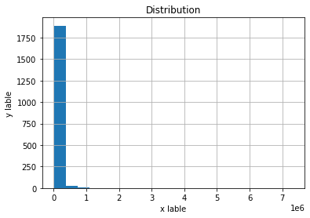

```python
#Find square root to establish how many bins are appropriate
import math
len(murders)
math.sqrt(2215)

#Plot the distribution
import matplotlib.pyplot as plt
murders['population'].hist(bins=20)
plt.title('Distribution')
plt.xlabel('x lable')
plt.ylabel('y lable')
plt.show()
```

```python
#Check the minimum and maximum value
print(murders['population'].min())
print(murders['population'].max())

#Determine bins based on quantiles
pop_bins = pd.qcut(murders['population'], q=5)
#Check the value counts of each bin to ensure they are balanced
pop_bins.value_counts()

#Create bin labels
pop_bin_labels = ['10000-13500', '13500-19000', '19000-29000', '29000-51500', '515000-7500000']
#Create bins
pop_bin = [10000, 13500, 19000, 29000, 51500, 7500000]
#Add new category
murders['pop_bins'] = pd.cut(murders['population'], bins=pop_bin, labels=pop_bin_labels)

murders.head()
```

```
10005
7322564
```

|  | communityname | state | population | householdsize | racepctblack | racePctWhite | racePctAsian | racePctHisp | agePct12t21 | agePct65up | pctUrban | medIncome | pctWFarmSelf | pctWInvInc | pctWPubAsst | pctWRetire | blackPerCap | indianPerCap | AsianPerCap | OtherPerCap | HispPerCap | PctPopUnderPov | PctLess9thGrade | PctBSorMore | PctEmplManu | PctEmplProfServ | PctOccupManu | MalePctDivorce | MalePctNevMarr | … |
| --- | --- | --- | --- | --- | --- | --- | --- | --- | --- | --- | --- | --- | --- | --- | --- | --- | --- | --- | --- | --- | --- | --- | --- | --- | --- | --- | --- | --- | --- | --- |
| 0 | BerkeleyHeightstownship | NJ | 11980 | 3.10 | 1.37 | 91.78 | 6.50 | 1.88 | 12.47 | 11.33 | 100.0 | 75122 | 1.55 | 70.20 | 1.03 | 18.39 | 13600 | 5725 | 27101 | 5115.0 | 22838 | 1.96 | 5.81 | 48.18 | 14.65 | 28.82 | 5.49 | 3.67 | 26.38 | … |
| 1 | Marpletownship | PA | 23123 | 2.82 | 0.80 | 95.57 | 3.44 | 0.85 | 11.01 | 17.18 | 100.0 | 47917 | 1.11 | 64.11 | 2.75 | 22.85 | 18137 | 0 | 20074 | 5250.0 | 12222 | 3.98 | 5.61 | 29.89 | 12.26 | 29.28 | 6.39 | 4.23 | 27.99 | … |
| 2 | Tigardcity | OR | 29344 | 2.43 | 0.74 | 94.33 | 3.43 | 2.35 | 11.36 | 10.28 | 100.0 | 35669 | 1.15 | 55.73 | 2.94 | 14.56 | 16644 | 21606 | 15528 | 5954.0 | 8405 | 4.75 | 2.80 | 30.13 | 15.95 | 21.52 | 8.79 | 10.10 | 25.78 | … |
| 4 | Springfieldcity | MO | 140494 | 2.45 | 2.51 | 95.65 | 0.90 | 0.95 | 18.09 | 13.26 | 100.0 | 21577 | 1.00 | 41.15 | 7.12 | 14.09 | 7382 | 10264 | 10753 | 7192.0 | 8104 | 17.78 | 8.76 | 20.66 | 14.31 | 26.83 | 14.72 | 11.40 | 33.32 | … |
| 5 | Norwoodtown | MA | 28700 | 2.60 | 1.60 | 96.57 | 1.47 | 1.10 | 11.17 | 14.42 | 100.0 | 42805 | 0.39 | 47.70 | 5.41 | 17.23 | 17342 | 21482 | 12639 | 21852.0 | 22594 | 4.01 | 4.49 | 27.01 | 14.02 | 27.17 | 8.50 | 5.97 | 36.05 | … |

```python
murders['pop_bins'].value_counts()
```

```
10000-13500       410
13500-19000       387
515000-7500000    384
19000-29000       382
29000-51500       356
Name: pop_bins, dtype: int64
```

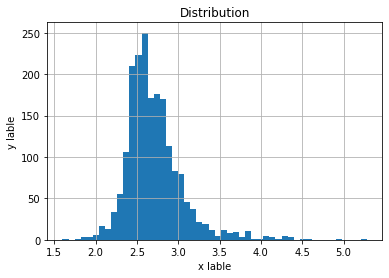

```python
murders['householdsize'].hist(bins=50)
plt.title('Distribution')
plt.xlabel('x lable')
plt.ylabel('y lable')
plt.show()

#SHAPIRO TEST HERE
```

```python
# apply normalization technique, using a range of [0,1]
murders['householdsize_bins'] = (murders['householdsize'] - murders['householdsize'].min()) / (murders['householdsize'].max() - murders['householdsize'].min())

murders.head()
```

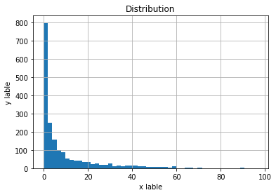

```python
murders['racepctblack'].hist(bins=50)
plt.title('Distribution')
plt.xlabel('x lable')
plt.ylabel('y lable')
plt.show()
```

```python
#Check the minimum and maximum value
print(murders['racepctblack'].min())
print(murders['racepctblack'].max())

#Determine bins based on quantiles
racepctblack_bins = pd.qcut(murders['racepctblack'], q=4)
#Check the value counts of each bin to ensure they are balanced
racepctblack_bins.value_counts()

#Create bin labels
racepctblack_bin_labels = ['0-0.8%', '0.9-2.8%', '2.9-11.1%', '11.2-97%']

#Create new bin category
murders['racepctblack_bins'] = pd.qcut(murders['racepctblack'],
                              q=4,
                              labels=racepctblack_bin_labels)

murders.head()
```

```
0.0
96.67
```

|  | communityname | state | population | householdsize | racepctblack | racePctWhite | racePctAsian | racePctHisp | agePct12t21 | agePct65up | pctUrban | medIncome | pctWFarmSelf | pctWInvInc | pctWPubAsst | pctWRetire | blackPerCap | indianPerCap | AsianPerCap | OtherPerCap | HispPerCap | PctPopUnderPov | PctLess9thGrade | PctBSorMore | PctEmplManu | PctEmplProfServ | PctOccupManu | MalePctDivorce | MalePctNevMarr | … |
| --- | --- | --- | --- | --- | --- | --- | --- | --- | --- | --- | --- | --- | --- | --- | --- | --- | --- | --- | --- | --- | --- | --- | --- | --- | --- | --- | --- | --- | --- | --- |
| 0 | BerkeleyHeightstownship | NJ | 11980 | 3.10 | 1.37 | 91.78 | 6.50 | 1.88 | 12.47 | 11.33 | 100.0 | 75122 | 1.55 | 70.20 | 1.03 | 18.39 | 13600 | 5725 | 27101 | 5115.0 | 22838 | 1.96 | 5.81 | 48.18 | 14.65 | 28.82 | 5.49 | 3.67 | 26.38 | … |
| 1 | Marpletownship | PA | 23123 | 2.82 | 0.80 | 95.57 | 3.44 | 0.85 | 11.01 | 17.18 | 100.0 | 47917 | 1.11 | 64.11 | 2.75 | 22.85 | 18137 | 0 | 20074 | 5250.0 | 12222 | 3.98 | 5.61 | 29.89 | 12.26 | 29.28 | 6.39 | 4.23 | 27.99 | … |
| 2 | Tigardcity | OR | 29344 | 2.43 | 0.74 | 94.33 | 3.43 | 2.35 | 11.36 | 10.28 | 100.0 | 35669 | 1.15 | 55.73 | 2.94 | 14.56 | 16644 | 21606 | 15528 | 5954.0 | 8405 | 4.75 | 2.80 | 30.13 | 15.95 | 21.52 | 8.79 | 10.10 | 25.78 | … |
| 4 | Springfieldcity | MO | 140494 | 2.45 | 2.51 | 95.65 | 0.90 | 0.95 | 18.09 | 13.26 | 100.0 | 21577 | 1.00 | 41.15 | 7.12 | 14.09 | 7382 | 10264 | 10753 | 7192.0 | 8104 | 17.78 | 8.76 | 20.66 | 14.31 | 26.83 | 14.72 | 11.40 | 33.32 | … |
| 5 | Norwoodtown | MA | 28700 | 2.60 | 1.60 | 96.57 | 1.47 | 1.10 | 11.17 | 14.42 | 100.0 | 42805 | 0.39 | 47.70 | 5.41 | 17.23 | 17342 | 21482 | 12639 | 21852.0 | 22594 | 4.01 | 4.49 | 27.01 | 14.02 | 27.17 | 8.50 | 5.97 | 36.05 | … |

```python
murders['racepctblack_bins'].value_counts()
```

```
0-0.8%       484
11.2-97%     480
2.9-11.1%    479
0.9-2.8%     476
Name: racepctblack_bins, dtype: int64
```

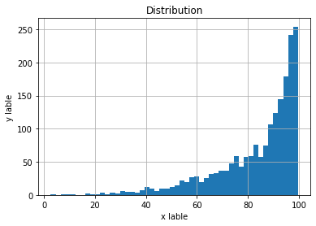

```python
murders['racePctWhite'].hist(bins=50)
plt.title('Distribution')
plt.xlabel('x lable')
plt.ylabel('y lable')
plt.show()
```

```python
#Check the minimum and maximum value
print(murders['racePctWhite'].min())
print(murders['racePctWhite'].max())

#Determine bins based on quantiles
racePctWhite_= pd.qcut(murders['racePctWhite'], q=4)
#Check the value counts of each bin to ensure they are balanced
racePctWhite_.value_counts()

#Create bin labels
racePctWhite_labels = ['0.0-75%','75-90%', '90-96%', '96-100%']
#Create bins
racePctWhite_bin = [0, 75, 90, 96, 100]
#Add new category
#murders_backup = murders
murders['racePctWhite_bins'] = pd.cut(murders['racePctWhite'], bins=racePctWhite_bin, labels=racePctWhite_labels)

#murders.head()
```

```
2.68
99.63
```

```python
murders['racePctWhite_bins'].value_counts()
```

```
75-90%     518
96-100%    474
90-96%     467
0.0-75%    460
Name: racePctWhite_bins, dtype: int64
```

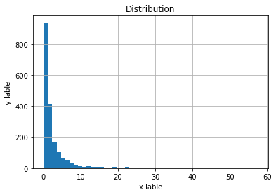

```python
murders['racePctAsian'].hist(bins=50)
plt.title('Distribution')
plt.xlabel('x lable')
plt.ylabel('y lable')
plt.show()
```

```python
#Check the minimum and maximum value
print(murders['racePctAsian'].min())
print(murders['racePctAsian'].max())


#Determine bins based on quantiles
racePctAsian_bins = pd.qcut(murders['racePctAsian'], q=4)
#Check the value counts of each bin to ensure they are balanced
racePctAsian_bins.value_counts()

#Create bin labels
racePctAsian_bin_labels = ['0.0-0.6%', '0.6-1.2%', '1.2-2.6%', '2.7-57.5%']

#Create new bin category
murders_backup = murders
murders['racePctAsian_bins'] = pd.qcut(murders['racePctAsian'],
                              q=4,
                              labels=racePctAsian_bin_labels)
#murders.head()
```

```
0.06
57.46
```

```python
murders['racePctAsian_bins'].value_counts()
```

```
0.0-0.6%     480
0.6-1.2%     480
2.7-57.5%    480
1.2-2.6%     479
Name: racePctAsian_bins, dtype: int64
```

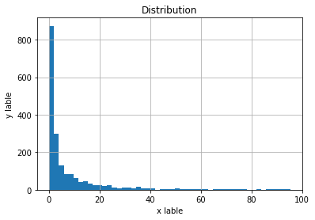

```python
murders[' racePctHisp'].hist(bins=50)
plt.title('Distribution')
plt.xlabel('x lable')
plt.ylabel('y lable')
plt.show()
```

```python
#Check the minimum and maximum value
print(murders[' racePctHisp'].min())
print(murders[' racePctHisp'].max())

#Determine bins based on quantiles
racePctHisp_bins = pd.qcut(murders[' racePctHisp'], q=4)
#Check the value counts of each bin to ensure they are balanced
racePctHisp_bins.value_counts()

#Create bin labels
racePctHisp_bin_labels = ['0.1-0.9%', '0.9-2.2%', '2.2-7.8%', '7.8-95.3%']

#Create new bin category
murders['racePctHisp_bins'] = pd.qcut(murders[' racePctHisp'],
                              q=4,
                              labels=racePctHisp_bin_labels)
murders.head()
```

```python
murders['racePctHisp_bins'].value_counts()
```

```
0.1-0.9%     485
2.2-7.8%     480
7.8-95.3%    479
0.9-2.2%     475
Name: racePctHisp_bins, dtype: int64
```

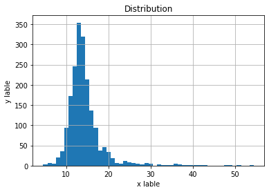

```python
murders['agePct12t21'].hist(bins=50)
plt.title('Distribution')
plt.xlabel('x lable')
plt.ylabel('y lable')
plt.show()
```

```python
# apply normalization technique, using a range of [0,1]
murders['agePct12t21_norm'] = (murders['agePct12t21'] - murders['agePct12t21'].min()) / (murders['agePct12t21'].max() - murders['agePct12t21'].min())

murders.head()
```

|  | communityname | state | population | householdsize | racepctblack | racePctWhite | racePctAsian | racePctHisp | agePct12t21 | agePct65up | pctUrban | medIncome | pctWFarmSelf | pctWInvInc | pctWPubAsst | pctWRetire | blackPerCap | indianPerCap | AsianPerCap | OtherPerCap | HispPerCap | PctPopUnderPov | PctLess9thGrade | PctBSorMore | PctEmplManu | PctEmplProfServ | PctOccupManu | MalePctDivorce | MalePctNevMarr | … |
| --- | --- | --- | --- | --- | --- | --- | --- | --- | --- | --- | --- | --- | --- | --- | --- | --- | --- | --- | --- | --- | --- | --- | --- | --- | --- | --- | --- | --- | --- | --- |
| 0 | BerkeleyHeightstownship | NJ | 11980 | 3.10 | 1.37 | 91.78 | 6.50 | 1.88 | 12.47 | 11.33 | 100.0 | 75122 | 1.55 | 70.20 | 1.03 | 18.39 | 13600 | 5725 | 27101 | 5115.0 | 22838 | 1.96 | 5.81 | 48.18 | 14.65 | 28.82 | 5.49 | 3.67 | 26.38 | … |
| 1 | Marpletownship | PA | 23123 | 2.82 | 0.80 | 95.57 | 3.44 | 0.85 | 11.01 | 17.18 | 100.0 | 47917 | 1.11 | 64.11 | 2.75 | 22.85 | 18137 | 0 | 20074 | 5250.0 | 12222 | 3.98 | 5.61 | 29.89 | 12.26 | 29.28 | 6.39 | 4.23 | 27.99 | … |
| 2 | Tigardcity | OR | 29344 | 2.43 | 0.74 | 94.33 | 3.43 | 2.35 | 11.36 | 10.28 | 100.0 | 35669 | 1.15 | 55.73 | 2.94 | 14.56 | 16644 | 21606 | 15528 | 5954.0 | 8405 | 4.75 | 2.80 | 30.13 | 15.95 | 21.52 | 8.79 | 10.10 | 25.78 | … |
| 4 | Springfieldcity | MO | 140494 | 2.45 | 2.51 | 95.65 | 0.90 | 0.95 | 18.09 | 13.26 | 100.0 | 21577 | 1.00 | 41.15 | 7.12 | 14.09 | 7382 | 10264 | 10753 | 7192.0 | 8104 | 17.78 | 8.76 | 20.66 | 14.31 | 26.83 | 14.72 | 11.40 | 33.32 | … |
| 5 | Norwoodtown | MA | 28700 | 2.60 | 1.60 | 96.57 | 1.47 | 1.10 | 11.17 | 14.42 | 100.0 | 42805 | 0.39 | 47.70 | 5.41 | 17.23 | 17342 | 21482 | 12639 | 21852.0 | 22594 | 4.01 | 4.49 | 27.01 | 14.02 | 27.17 | 8.50 | 5.97 | 36.05 | … |

```python
murders = murders.drop(['householdsize_bins', 'agePct12t21_bins'], axis=1)
```

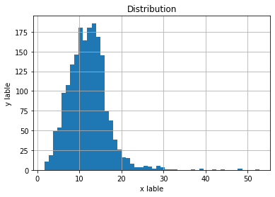

```python
murders[' agePct65up'].hist(bins=50)
plt.title('Distribution')
plt.xlabel('x lable')
plt.ylabel('y lable')
plt.show()
```

```python
# apply normalization technique, using a range of [0,1]
murders['agePct65up_norm'] = (murders[' agePct65up'] - murders[' agePct65up'].min()) / (murders[' agePct65up'].max() - murders[' agePct65up'].min())

murders.head()
```

|  | communityname | state | population | householdsize | racepctblack | racePctWhite | racePctAsian | racePctHisp | agePct12t21 | agePct65up | pctUrban | medIncome | pctWFarmSelf | pctWInvInc | pctWPubAsst | pctWRetire | blackPerCap | indianPerCap | AsianPerCap | OtherPerCap | HispPerCap | PctPopUnderPov | PctLess9thGrade | PctBSorMore | PctEmplManu | PctEmplProfServ | PctOccupManu | MalePctDivorce | MalePctNevMarr | … |
| --- | --- | --- | --- | --- | --- | --- | --- | --- | --- | --- | --- | --- | --- | --- | --- | --- | --- | --- | --- | --- | --- | --- | --- | --- | --- | --- | --- | --- | --- | --- |
| 0 | BerkeleyHeightstownship | NJ | 11980 | 3.10 | 1.37 | 91.78 | 6.50 | 1.88 | 12.47 | 11.33 | 100.0 | 75122 | 1.55 | 70.20 | 1.03 | 18.39 | 13600 | 5725 | 27101 | 5115.0 | 22838 | 1.96 | 5.81 | 48.18 | 14.65 | 28.82 | 5.49 | 3.67 | 26.38 | … |
| 1 | Marpletownship | PA | 23123 | 2.82 | 0.80 | 95.57 | 3.44 | 0.85 | 11.01 | 17.18 | 100.0 | 47917 | 1.11 | 64.11 | 2.75 | 22.85 | 18137 | 0 | 20074 | 5250.0 | 12222 | 3.98 | 5.61 | 29.89 | 12.26 | 29.28 | 6.39 | 4.23 | 27.99 | … |
| 2 | Tigardcity | OR | 29344 | 2.43 | 0.74 | 94.33 | 3.43 | 2.35 | 11.36 | 10.28 | 100.0 | 35669 | 1.15 | 55.73 | 2.94 | 14.56 | 16644 | 21606 | 15528 | 5954.0 | 8405 | 4.75 | 2.80 | 30.13 | 15.95 | 21.52 | 8.79 | 10.10 | 25.78 | … |
| 4 | Springfieldcity | MO | 140494 | 2.45 | 2.51 | 95.65 | 0.90 | 0.95 | 18.09 | 13.26 | 100.0 | 21577 | 1.00 | 41.15 | 7.12 | 14.09 | 7382 | 10264 | 10753 | 7192.0 | 8104 | 17.78 | 8.76 | 20.66 | 14.31 | 26.83 | 14.72 | 11.40 | 33.32 | … |
| 5 | Norwoodtown | MA | 28700 | 2.60 | 1.60 | 96.57 | 1.47 | 1.10 | 11.17 | 14.42 | 100.0 | 42805 | 0.39 | 47.70 | 5.41 | 17.23 | 17342 | 21482 | 12639 | 21852.0 | 22594 | 4.01 | 4.49 | 27.01 | 14.02 | 27.17 | 8.50 | 5.97 | 36.05 | … |

```python
murders = murders.drop(['agePct65up_bins'], axis=1)
```

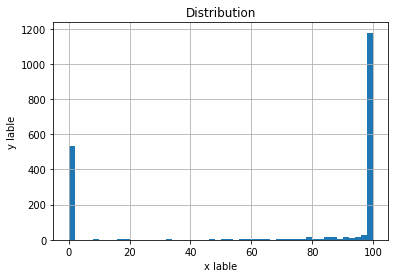

```python
murders[' pctUrban'].hist(bins=50)
plt.title('Distribution')
plt.xlabel('x lable')
plt.ylabel('y lable')
plt.show()
```

```python
#Check the minimum and maximum value
print(murders[' pctUrban'].min())
print(murders[' pctUrban'].max())

#Determine bins based on quantiles
print(murders[' pctUrban'].describe())

#Create bin labels
pctUrban_bin_labels = ['0.0%', '0.1-99%', '100%']
#Create bins
pctUrban_bin = [-1, 0.1, 99, 100]
#Add new category
murders_backup = murders
murders['pctUrban_bins'] = pd.cut(murders[' pctUrban'], bins=pctUrban_bin, labels=pctUrban_bin_labels)
murders.head()
```

```
0.0
100.0
count    1919.000000
mean       69.758046
std        44.375875
min         0.000000
25%         0.000000
50%       100.000000
75%       100.000000
max       100.000000
Name:  pctUrban, dtype: float64
```

|  | communityname | state | population | householdsize | racepctblack | racePctWhite | racePctAsian | racePctHisp | agePct12t21 | agePct65up | pctUrban | medIncome | pctWFarmSelf | pctWInvInc | pctWPubAsst | pctWRetire | blackPerCap | indianPerCap | AsianPerCap | OtherPerCap | HispPerCap | PctPopUnderPov | PctLess9thGrade | PctBSorMore | PctEmplManu | PctEmplProfServ | PctOccupManu | MalePctDivorce | MalePctNevMarr | … |
| --- | --- | --- | --- | --- | --- | --- | --- | --- | --- | --- | --- | --- | --- | --- | --- | --- | --- | --- | --- | --- | --- | --- | --- | --- | --- | --- | --- | --- | --- | --- |
| 0 | BerkeleyHeightstownship | NJ | 11980 | 3.10 | 1.37 | 91.78 | 6.50 | 1.88 | 12.47 | 11.33 | 100.0 | 75122 | 1.55 | 70.20 | 1.03 | 18.39 | 13600 | 5725 | 27101 | 5115.0 | 22838 | 1.96 | 5.81 | 48.18 | 14.65 | 28.82 | 5.49 | 3.67 | 26.38 | … |
| 1 | Marpletownship | PA | 23123 | 2.82 | 0.80 | 95.57 | 3.44 | 0.85 | 11.01 | 17.18 | 100.0 | 47917 | 1.11 | 64.11 | 2.75 | 22.85 | 18137 | 0 | 20074 | 5250.0 | 12222 | 3.98 | 5.61 | 29.89 | 12.26 | 29.28 | 6.39 | 4.23 | 27.99 | … |
| 2 | Tigardcity | OR | 29344 | 2.43 | 0.74 | 94.33 | 3.43 | 2.35 | 11.36 | 10.28 | 100.0 | 35669 | 1.15 | 55.73 | 2.94 | 14.56 | 16644 | 21606 | 15528 | 5954.0 | 8405 | 4.75 | 2.80 | 30.13 | 15.95 | 21.52 | 8.79 | 10.10 | 25.78 | … |
| 4 | Springfieldcity | MO | 140494 | 2.45 | 2.51 | 95.65 | 0.90 | 0.95 | 18.09 | 13.26 | 100.0 | 21577 | 1.00 | 41.15 | 7.12 | 14.09 | 7382 | 10264 | 10753 | 7192.0 | 8104 | 17.78 | 8.76 | 20.66 | 14.31 | 26.83 | 14.72 | 11.40 | 33.32 | … |
| 5 | Norwoodtown | MA | 28700 | 2.60 | 1.60 | 96.57 | 1.47 | 1.10 | 11.17 | 14.42 | 100.0 | 42805 | 0.39 | 47.70 | 5.41 | 17.23 | 17342 | 21482 | 12639 | 21852.0 | 22594 | 4.01 | 4.49 | 27.01 | 14.02 | 27.17 | 8.50 | 5.97 | 36.05 | … |

```python
murders['pctUrban_bins'].value_counts()

#This distribution was not able to be balanced in any meaningful way
#I decided to leave the values as is, changing them to a binary yes/no would have been unbalanced and would have lost more information
```

```
100%       1158
0.0%        532
0.1-99%     229
Name: pctUrban_bins, dtype: int64
```

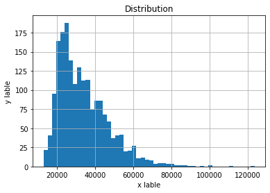

```python
murders[' medIncome'].hist(bins=50)
plt.title('Distribution')
plt.xlabel('x lable')
plt.ylabel('y lable')
plt.show()
```

```python
#Check the minimum and maximum value
print(murders[' medIncome'].min())
print(murders[' medIncome'].max())

#Determine bins based on quantiles
medIncome_ = pd.qcut(murders[' medIncome'], q=4)
#Check the value counts of each bin to ensure they are balanced
medIncome_.value_counts()

#Create bin labels
medIncome_labels = ['$8,000-$24,000', '$24,000-$32,000', '$32,000-$42,000', '42,000-$125,000']
#Create bins
medIncome_bin = [8865, 24000, 32000, 42000, 123625]
#Add new category
murders_backup = murders
murders['medIncome_bins'] = pd.cut(murders[' medIncome'], bins=medIncome_bin, labels=medIncome_labels)
murders.head()
```

```
12908
123625
```

|  | communityname | state | population | householdsize | racepctblack | racePctWhite | racePctAsian | racePctHisp | agePct12t21 | agePct65up | pctUrban | medIncome | pctWFarmSelf | pctWInvInc | pctWPubAsst | pctWRetire | blackPerCap | indianPerCap | AsianPerCap | OtherPerCap | HispPerCap | PctPopUnderPov | PctLess9thGrade | PctBSorMore | PctEmplManu | PctEmplProfServ | PctOccupManu | MalePctDivorce | MalePctNevMarr | … |
| --- | --- | --- | --- | --- | --- | --- | --- | --- | --- | --- | --- | --- | --- | --- | --- | --- | --- | --- | --- | --- | --- | --- | --- | --- | --- | --- | --- | --- | --- | --- |
| 0 | BerkeleyHeightstownship | NJ | 11980 | 3.10 | 1.37 | 91.78 | 6.50 | 1.88 | 12.47 | 11.33 | 100.0 | 75122 | 1.55 | 70.20 | 1.03 | 18.39 | 13600 | 5725 | 27101 | 5115.0 | 22838 | 1.96 | 5.81 | 48.18 | 14.65 | 28.82 | 5.49 | 3.67 | 26.38 | … |
| 1 | Marpletownship | PA | 23123 | 2.82 | 0.80 | 95.57 | 3.44 | 0.85 | 11.01 | 17.18 | 100.0 | 47917 | 1.11 | 64.11 | 2.75 | 22.85 | 18137 | 0 | 20074 | 5250.0 | 12222 | 3.98 | 5.61 | 29.89 | 12.26 | 29.28 | 6.39 | 4.23 | 27.99 | … |
| 2 | Tigardcity | OR | 29344 | 2.43 | 0.74 | 94.33 | 3.43 | 2.35 | 11.36 | 10.28 | 100.0 | 35669 | 1.15 | 55.73 | 2.94 | 14.56 | 16644 | 21606 | 15528 | 5954.0 | 8405 | 4.75 | 2.80 | 30.13 | 15.95 | 21.52 | 8.79 | 10.10 | 25.78 | … |
| 4 | Springfieldcity | MO | 140494 | 2.45 | 2.51 | 95.65 | 0.90 | 0.95 | 18.09 | 13.26 | 100.0 | 21577 | 1.00 | 41.15 | 7.12 | 14.09 | 7382 | 10264 | 10753 | 7192.0 | 8104 | 17.78 | 8.76 | 20.66 | 14.31 | 26.83 | 14.72 | 11.40 | 33.32 | … |
| 5 | Norwoodtown | MA | 28700 | 2.60 | 1.60 | 96.57 | 1.47 | 1.10 | 11.17 | 14.42 | 100.0 | 42805 | 0.39 | 47.70 | 5.41 | 17.23 | 17342 | 21482 | 12639 | 21852.0 | 22594 | 4.01 | 4.49 | 27.01 | 14.02 | 27.17 | 8.50 | 5.97 | 36.05 | … |

```python
murders['medIncome_bins'].value_counts()
```

```
$24,000-$32,000    511
$8,000-$24,000     500
42,000-$125,000    458
$32,000-$42,000    450
Name: medIncome_bins, dtype: int64
```

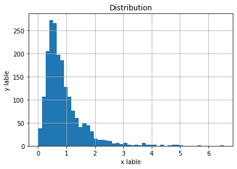

```python
murders['pctWFarmSelf'].hist(bins=50)
plt.title('Distribution')
plt.xlabel('x lable')
plt.ylabel('y lable')
plt.show()
```

```python
#Check the minimum and maximum value
print(murders['pctWFarmSelf'].min())
print(murders['pctWFarmSelf'].max())

#Determine bins based on quantiles
murders['pctWFarmSelf'].describe()

#Create bin labels
pctWFarmSelf_labels = ['0-0.5%', '0.5-0.7%', '0.7-1.0%', '1.0-7.0%']
#Create bins
pctWFarmSelf_bin = [-1, 0.5, 0.7, 1, 7]
#Add new category
murders['pctWFarmSelf_bins'] = pd.cut(murders['pctWFarmSelf'], bins=pctWFarmSelf_bin, labels=pctWFarmSelf_labels)
murders.head()
```

```
0.0
6.53
```

|  | communityname | state | population | householdsize | racepctblack | racePctWhite | racePctAsian | racePctHisp | agePct12t21 | agePct65up | pctUrban | medIncome | pctWFarmSelf | pctWInvInc | pctWPubAsst | pctWRetire | blackPerCap | indianPerCap | AsianPerCap | OtherPerCap | HispPerCap | PctPopUnderPov | PctLess9thGrade | PctBSorMore | PctEmplManu | PctEmplProfServ | PctOccupManu | MalePctDivorce | MalePctNevMarr | … |
| --- | --- | --- | --- | --- | --- | --- | --- | --- | --- | --- | --- | --- | --- | --- | --- | --- | --- | --- | --- | --- | --- | --- | --- | --- | --- | --- | --- | --- | --- | --- |
| 0 | BerkeleyHeightstownship | NJ | 11980 | 3.10 | 1.37 | 91.78 | 6.50 | 1.88 | 12.47 | 11.33 | 100.0 | 75122 | 1.55 | 70.20 | 1.03 | 18.39 | 13600 | 5725 | 27101 | 5115.0 | 22838 | 1.96 | 5.81 | 48.18 | 14.65 | 28.82 | 5.49 | 3.67 | 26.38 | … |
| 1 | Marpletownship | PA | 23123 | 2.82 | 0.80 | 95.57 | 3.44 | 0.85 | 11.01 | 17.18 | 100.0 | 47917 | 1.11 | 64.11 | 2.75 | 22.85 | 18137 | 0 | 20074 | 5250.0 | 12222 | 3.98 | 5.61 | 29.89 | 12.26 | 29.28 | 6.39 | 4.23 | 27.99 | … |
| 2 | Tigardcity | OR | 29344 | 2.43 | 0.74 | 94.33 | 3.43 | 2.35 | 11.36 | 10.28 | 100.0 | 35669 | 1.15 | 55.73 | 2.94 | 14.56 | 16644 | 21606 | 15528 | 5954.0 | 8405 | 4.75 | 2.80 | 30.13 | 15.95 | 21.52 | 8.79 | 10.10 | 25.78 | … |
| 4 | Springfieldcity | MO | 140494 | 2.45 | 2.51 | 95.65 | 0.90 | 0.95 | 18.09 | 13.26 | 100.0 | 21577 | 1.00 | 41.15 | 7.12 | 14.09 | 7382 | 10264 | 10753 | 7192.0 | 8104 | 17.78 | 8.76 | 20.66 | 14.31 | 26.83 | 14.72 | 11.40 | 33.32 | … |
| 5 | Norwoodtown | MA | 28700 | 2.60 | 1.60 | 96.57 | 1.47 | 1.10 | 11.17 | 14.42 | 100.0 | 42805 | 0.39 | 47.70 | 5.41 | 17.23 | 17342 | 21482 | 12639 | 21852.0 | 22594 | 4.01 | 4.49 | 27.01 | 14.02 | 27.17 | 8.50 | 5.97 | 36.05 | … |

```python
murders['pctWFarmSelf_bins'].value_counts()
```

```
0-0.5%      578
1.0-7.0%    553
0.5-0.7%    401
0.7-1.0%    387
Name: pctWFarmSelf_bins, dtype: int64
```

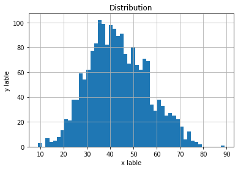

```python
murders['pctWInvInc'].hist(bins=50)
plt.title('Distribution')
plt.xlabel('x lable')
plt.ylabel('y lable')
plt.show()
```

```python
# apply normalization technique, using a range of [0,1]
murders['pctWInvInc_norm'] = (murders['pctWInvInc'] - murders['pctWInvInc'].min()) / (murders['pctWInvInc'].max() - murders['pctWInvInc'].min())

murders.head()
```

|  | communityname | state | population | householdsize | racepctblack | racePctWhite | racePctAsian | racePctHisp | agePct12t21 | agePct65up | pctUrban | medIncome | pctWFarmSelf | pctWInvInc | pctWPubAsst | pctWRetire | blackPerCap | indianPerCap | AsianPerCap | OtherPerCap | HispPerCap | PctPopUnderPov | PctLess9thGrade | PctBSorMore | PctEmplManu | PctEmplProfServ | PctOccupManu | MalePctDivorce | MalePctNevMarr | … |
| --- | --- | --- | --- | --- | --- | --- | --- | --- | --- | --- | --- | --- | --- | --- | --- | --- | --- | --- | --- | --- | --- | --- | --- | --- | --- | --- | --- | --- | --- | --- |
| 0 | BerkeleyHeightstownship | NJ | 11980 | 3.10 | 1.37 | 91.78 | 6.50 | 1.88 | 12.47 | 11.33 | 100.0 | 75122 | 1.55 | 70.20 | 1.03 | 18.39 | 13600 | 5725 | 27101 | 5115.0 | 22838 | 1.96 | 5.81 | 48.18 | 14.65 | 28.82 | 5.49 | 3.67 | 26.38 | … |
| 1 | Marpletownship | PA | 23123 | 2.82 | 0.80 | 95.57 | 3.44 | 0.85 | 11.01 | 17.18 | 100.0 | 47917 | 1.11 | 64.11 | 2.75 | 22.85 | 18137 | 0 | 20074 | 5250.0 | 12222 | 3.98 | 5.61 | 29.89 | 12.26 | 29.28 | 6.39 | 4.23 | 27.99 | … |
| 2 | Tigardcity | OR | 29344 | 2.43 | 0.74 | 94.33 | 3.43 | 2.35 | 11.36 | 10.28 | 100.0 | 35669 | 1.15 | 55.73 | 2.94 | 14.56 | 16644 | 21606 | 15528 | 5954.0 | 8405 | 4.75 | 2.80 | 30.13 | 15.95 | 21.52 | 8.79 | 10.10 | 25.78 | … |
| 4 | Springfieldcity | MO | 140494 | 2.45 | 2.51 | 95.65 | 0.90 | 0.95 | 18.09 | 13.26 | 100.0 | 21577 | 1.00 | 41.15 | 7.12 | 14.09 | 7382 | 10264 | 10753 | 7192.0 | 8104 | 17.78 | 8.76 | 20.66 | 14.31 | 26.83 | 14.72 | 11.40 | 33.32 | … |
| 5 | Norwoodtown | MA | 28700 | 2.60 | 1.60 | 96.57 | 1.47 | 1.10 | 11.17 | 14.42 | 100.0 | 42805 | 0.39 | 47.70 | 5.41 | 17.23 | 17342 | 21482 | 12639 | 21852.0 | 22594 | 4.01 | 4.49 | 27.01 | 14.02 | 27.17 | 8.50 | 5.97 | 36.05 | … |

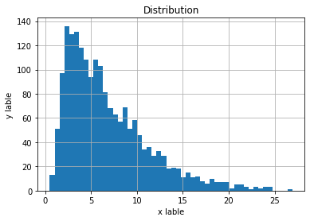

```python
murders[' pctWPubAsst'].hist(bins=50)
plt.title('Distribution')
plt.xlabel('x lable')
plt.ylabel('y lable')
plt.show()
```

```python
#Check the minimum and maximum value
print(murders[' pctWPubAsst'].min())
print(murders[' pctWPubAsst'].max())

#Determine bins based on quantiles
pctWPubAsst_ = pd.qcut(murders[' pctWPubAsst'], q=4)
#Check the value counts of each bin to ensure they are balanced
pctWPubAsst_.value_counts()

#Create bin labels
pctWPubAsst_labels = ['0-3%', '3-5%', '5-8%', '8-45%']
#Create bins
pctWPubAsst_bin = [0, 3, 5, 8.5, 45]
#Add new category
murders['pctWPubAsst_bins'] = pd.cut(murders[' pctWPubAsst'], bins=pctWPubAsst_bin, labels=pctWPubAsst_labels)
murders.head()
```

```
0.5
26.92
```

|  | communityname | state | population | householdsize | racepctblack | racePctWhite | racePctAsian | racePctHisp | agePct12t21 | agePct65up | pctUrban | medIncome | pctWFarmSelf | pctWInvInc | pctWPubAsst | pctWRetire | blackPerCap | indianPerCap | AsianPerCap | OtherPerCap | HispPerCap | PctPopUnderPov | PctLess9thGrade | PctBSorMore | PctEmplManu | PctEmplProfServ | PctOccupManu | MalePctDivorce | MalePctNevMarr | … |
| --- | --- | --- | --- | --- | --- | --- | --- | --- | --- | --- | --- | --- | --- | --- | --- | --- | --- | --- | --- | --- | --- | --- | --- | --- | --- | --- | --- | --- | --- | --- |
| 0 | BerkeleyHeightstownship | NJ | 11980 | 3.10 | 1.37 | 91.78 | 6.50 | 1.88 | 12.47 | 11.33 | 100.0 | 75122 | 1.55 | 70.20 | 1.03 | 18.39 | 13600 | 5725 | 27101 | 5115.0 | 22838 | 1.96 | 5.81 | 48.18 | 14.65 | 28.82 | 5.49 | 3.67 | 26.38 | … |
| 1 | Marpletownship | PA | 23123 | 2.82 | 0.80 | 95.57 | 3.44 | 0.85 | 11.01 | 17.18 | 100.0 | 47917 | 1.11 | 64.11 | 2.75 | 22.85 | 18137 | 0 | 20074 | 5250.0 | 12222 | 3.98 | 5.61 | 29.89 | 12.26 | 29.28 | 6.39 | 4.23 | 27.99 | … |
| 2 | Tigardcity | OR | 29344 | 2.43 | 0.74 | 94.33 | 3.43 | 2.35 | 11.36 | 10.28 | 100.0 | 35669 | 1.15 | 55.73 | 2.94 | 14.56 | 16644 | 21606 | 15528 | 5954.0 | 8405 | 4.75 | 2.80 | 30.13 | 15.95 | 21.52 | 8.79 | 10.10 | 25.78 | … |
| 4 | Springfieldcity | MO | 140494 | 2.45 | 2.51 | 95.65 | 0.90 | 0.95 | 18.09 | 13.26 | 100.0 | 21577 | 1.00 | 41.15 | 7.12 | 14.09 | 7382 | 10264 | 10753 | 7192.0 | 8104 | 17.78 | 8.76 | 20.66 | 14.31 | 26.83 | 14.72 | 11.40 | 33.32 | … |
| 5 | Norwoodtown | MA | 28700 | 2.60 | 1.60 | 96.57 | 1.47 | 1.10 | 11.17 | 14.42 | 100.0 | 42805 | 0.39 | 47.70 | 5.41 | 17.23 | 17342 | 21482 | 12639 | 21852.0 | 22594 | 4.01 | 4.49 | 27.01 | 14.02 | 27.17 | 8.50 | 5.97 | 36.05 | … |

```python
murders['pctWPubAsst_bins'].value_counts()
```

```
8-45%    552
5-8%     532
3-5%     441
0-3%     394
Name: pctWPubAsst_bins, dtype: int64
```

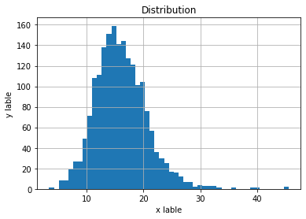

```python
murders['pctWRetire'].hist(bins=50)
plt.title('Distribution')
plt.xlabel('x lable')
plt.ylabel('y lable')
plt.show()
```

```python
# apply normalization technique, using a range of [0,1]
murders['pctWRetire_norm'] = (murders['pctWRetire'] - murders['pctWRetire'].min()) / (murders['pctWRetire'].max() - murders['pctWRetire'].min())

murders.head()
```

|  | communityname | state | population | householdsize | racepctblack | racePctWhite | racePctAsian | racePctHisp | agePct12t21 | agePct65up | pctUrban | medIncome | pctWFarmSelf | pctWInvInc | pctWPubAsst | pctWRetire | blackPerCap | indianPerCap | AsianPerCap | OtherPerCap | HispPerCap | PctPopUnderPov | PctLess9thGrade | PctBSorMore | PctEmplManu | PctEmplProfServ | PctOccupManu | MalePctDivorce | MalePctNevMarr | … |
| --- | --- | --- | --- | --- | --- | --- | --- | --- | --- | --- | --- | --- | --- | --- | --- | --- | --- | --- | --- | --- | --- | --- | --- | --- | --- | --- | --- | --- | --- | --- |
| 0 | BerkeleyHeightstownship | NJ | 11980 | 3.10 | 1.37 | 91.78 | 6.50 | 1.88 | 12.47 | 11.33 | 100.0 | 75122 | 1.55 | 70.20 | 1.03 | 18.39 | 13600 | 5725 | 27101 | 5115.0 | 22838 | 1.96 | 5.81 | 48.18 | 14.65 | 28.82 | 5.49 | 3.67 | 26.38 | … |
| 1 | Marpletownship | PA | 23123 | 2.82 | 0.80 | 95.57 | 3.44 | 0.85 | 11.01 | 17.18 | 100.0 | 47917 | 1.11 | 64.11 | 2.75 | 22.85 | 18137 | 0 | 20074 | 5250.0 | 12222 | 3.98 | 5.61 | 29.89 | 12.26 | 29.28 | 6.39 | 4.23 | 27.99 | … |
| 2 | Tigardcity | OR | 29344 | 2.43 | 0.74 | 94.33 | 3.43 | 2.35 | 11.36 | 10.28 | 100.0 | 35669 | 1.15 | 55.73 | 2.94 | 14.56 | 16644 | 21606 | 15528 | 5954.0 | 8405 | 4.75 | 2.80 | 30.13 | 15.95 | 21.52 | 8.79 | 10.10 | 25.78 | … |
| 4 | Springfieldcity | MO | 140494 | 2.45 | 2.51 | 95.65 | 0.90 | 0.95 | 18.09 | 13.26 | 100.0 | 21577 | 1.00 | 41.15 | 7.12 | 14.09 | 7382 | 10264 | 10753 | 7192.0 | 8104 | 17.78 | 8.76 | 20.66 | 14.31 | 26.83 | 14.72 | 11.40 | 33.32 | … |
| 5 | Norwoodtown | MA | 28700 | 2.60 | 1.60 | 96.57 | 1.47 | 1.10 | 11.17 | 14.42 | 100.0 | 42805 | 0.39 | 47.70 | 5.41 | 17.23 | 17342 | 21482 | 12639 | 21852.0 | 22594 | 4.01 | 4.49 | 27.01 | 14.02 | 27.17 | 8.50 | 5.97 | 36.05 | … |

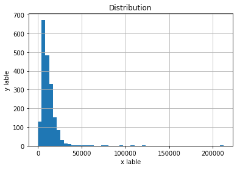

```python
murders['blackPerCap'].hist(bins=50)
plt.title('Distribution')
plt.xlabel('x lable')
plt.ylabel('y lable')
plt.show()
```

```python
#Check the minimum and maximum value
print(murders['blackPerCap'].min())
print(murders['blackPerCap'].max())

#Determine bins based on quantiles
blackPerCap_ = pd.qcut(murders['blackPerCap'], q=4)
#Check the value counts of each bin to ensure they are balanced
blackPerCap_.value_counts()

#Create bin labels
blackPerCap_labels = ['0-7000', '6500-10000', '10000-15000', '15000-250000']
#Create bins
blackPerCap_bin = [-1, 7000, 10000, 15000, 250000]
#Add new catrgory
murders['blackPerCap_bins'] = pd.cut(murders['blackPerCap'], bins=blackPerCap_bin, labels=blackPerCap_labels)
murders.head()
```

```
0
212120
```

|  | communityname | state | population | householdsize | racepctblack | racePctWhite | racePctAsian | racePctHisp | agePct12t21 | agePct65up | pctUrban | medIncome | pctWFarmSelf | pctWInvInc | pctWPubAsst | pctWRetire | blackPerCap | indianPerCap | AsianPerCap | OtherPerCap | HispPerCap | PctPopUnderPov | PctLess9thGrade | PctBSorMore | PctEmplManu | PctEmplProfServ | PctOccupManu | MalePctDivorce | MalePctNevMarr | … |
| --- | --- | --- | --- | --- | --- | --- | --- | --- | --- | --- | --- | --- | --- | --- | --- | --- | --- | --- | --- | --- | --- | --- | --- | --- | --- | --- | --- | --- | --- | --- |
| 0 | BerkeleyHeightstownship | NJ | 11980 | 3.10 | 1.37 | 91.78 | 6.50 | 1.88 | 12.47 | 11.33 | 100.0 | 75122 | 1.55 | 70.20 | 1.03 | 18.39 | 13600 | 5725 | 27101 | 5115.0 | 22838 | 1.96 | 5.81 | 48.18 | 14.65 | 28.82 | 5.49 | 3.67 | 26.38 | … |
| 1 | Marpletownship | PA | 23123 | 2.82 | 0.80 | 95.57 | 3.44 | 0.85 | 11.01 | 17.18 | 100.0 | 47917 | 1.11 | 64.11 | 2.75 | 22.85 | 18137 | 0 | 20074 | 5250.0 | 12222 | 3.98 | 5.61 | 29.89 | 12.26 | 29.28 | 6.39 | 4.23 | 27.99 | … |
| 2 | Tigardcity | OR | 29344 | 2.43 | 0.74 | 94.33 | 3.43 | 2.35 | 11.36 | 10.28 | 100.0 | 35669 | 1.15 | 55.73 | 2.94 | 14.56 | 16644 | 21606 | 15528 | 5954.0 | 8405 | 4.75 | 2.80 | 30.13 | 15.95 | 21.52 | 8.79 | 10.10 | 25.78 | … |
| 4 | Springfieldcity | MO | 140494 | 2.45 | 2.51 | 95.65 | 0.90 | 0.95 | 18.09 | 13.26 | 100.0 | 21577 | 1.00 | 41.15 | 7.12 | 14.09 | 7382 | 10264 | 10753 | 7192.0 | 8104 | 17.78 | 8.76 | 20.66 | 14.31 | 26.83 | 14.72 | 11.40 | 33.32 | … |
| 5 | Norwoodtown | MA | 28700 | 2.60 | 1.60 | 96.57 | 1.47 | 1.10 | 11.17 | 14.42 | 100.0 | 42805 | 0.39 | 47.70 | 5.41 | 17.23 | 17342 | 21482 | 12639 | 21852.0 | 22594 | 4.01 | 4.49 | 27.01 | 14.02 | 27.17 | 8.50 | 5.97 | 36.05 | … |

```python
murders['blackPerCap_bins'].value_counts()
```

```
0-7000          536
10000-15000     498
6500-10000      449
15000-250000    436
Name: blackPerCap_bins, dtype: int64
```

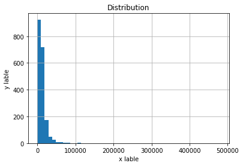

```python
murders['indianPerCap'].hist(bins=50)
plt.title('Distribution')
plt.xlabel('x lable')
plt.ylabel('y lable')
plt.show()
```

```python
#Check the minimum and maximum value
print(murders['indianPerCap'].min())
print(murders['indianPerCap'].max())

#Determine bins based on quantiles
indianPerCap_ = pd.qcut(murders['indianPerCap'], q=4)
#Check the value counts of each bin to ensure they are balanced
indianPerCap_.value_counts()

#Create bin labels
indianPerCap_labels = ['0-6500', '6500-10000', '10000-15000', '15000-500000']
#Create bins
indianPerCap_bin = [-1, 6500, 10000, 15000, 500000]
#Add new category
murders['indianPerCap_bins'] = pd.cut(murders['indianPerCap'], bins=indianPerCap_bin, labels=indianPerCap_labels)
murders.head()
```

```
0
480000
```

|  | communityname | state | population | householdsize | racepctblack | racePctWhite | racePctAsian | racePctHisp | agePct12t21 | agePct65up | pctUrban | medIncome | pctWFarmSelf | pctWInvInc | pctWPubAsst | pctWRetire | blackPerCap | indianPerCap | AsianPerCap | OtherPerCap | HispPerCap | PctPopUnderPov | PctLess9thGrade | PctBSorMore | PctEmplManu | PctEmplProfServ | PctOccupManu | MalePctDivorce | MalePctNevMarr | … |
| --- | --- | --- | --- | --- | --- | --- | --- | --- | --- | --- | --- | --- | --- | --- | --- | --- | --- | --- | --- | --- | --- | --- | --- | --- | --- | --- | --- | --- | --- | --- |
| 0 | BerkeleyHeightstownship | NJ | 11980 | 3.10 | 1.37 | 91.78 | 6.50 | 1.88 | 12.47 | 11.33 | 100.0 | 75122 | 1.55 | 70.20 | 1.03 | 18.39 | 13600 | 5725 | 27101 | 5115.0 | 22838 | 1.96 | 5.81 | 48.18 | 14.65 | 28.82 | 5.49 | 3.67 | 26.38 | … |
| 1 | Marpletownship | PA | 23123 | 2.82 | 0.80 | 95.57 | 3.44 | 0.85 | 11.01 | 17.18 | 100.0 | 47917 | 1.11 | 64.11 | 2.75 | 22.85 | 18137 | 0 | 20074 | 5250.0 | 12222 | 3.98 | 5.61 | 29.89 | 12.26 | 29.28 | 6.39 | 4.23 | 27.99 | … |
| 2 | Tigardcity | OR | 29344 | 2.43 | 0.74 | 94.33 | 3.43 | 2.35 | 11.36 | 10.28 | 100.0 | 35669 | 1.15 | 55.73 | 2.94 | 14.56 | 16644 | 21606 | 15528 | 5954.0 | 8405 | 4.75 | 2.80 | 30.13 | 15.95 | 21.52 | 8.79 | 10.10 | 25.78 | … |
| 4 | Springfieldcity | MO | 140494 | 2.45 | 2.51 | 95.65 | 0.90 | 0.95 | 18.09 | 13.26 | 100.0 | 21577 | 1.00 | 41.15 | 7.12 | 14.09 | 7382 | 10264 | 10753 | 7192.0 | 8104 | 17.78 | 8.76 | 20.66 | 14.31 | 26.83 | 14.72 | 11.40 | 33.32 | … |
| 5 | Norwoodtown | MA | 28700 | 2.60 | 1.60 | 96.57 | 1.47 | 1.10 | 11.17 | 14.42 | 100.0 | 42805 | 0.39 | 47.70 | 5.41 | 17.23 | 17342 | 21482 | 12639 | 21852.0 | 22594 | 4.01 | 4.49 | 27.01 | 14.02 | 27.17 | 8.50 | 5.97 | 36.05 | … |

```python
murders['indianPerCap_bins'].value_counts()
```

```
0-6500          497
10000-15000     481
6500-10000      474
15000-500000    467
Name: indianPerCap_bins, dtype: int64
```

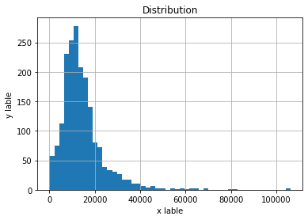

```python
murders['AsianPerCap'].hist(bins=50)
plt.title('Distribution')
plt.xlabel('x lable')
plt.ylabel('y lable')
plt.show()
```

```python
#Check the minimum and maximum value
print(murders['AsianPerCap'].min())
print(murders['AsianPerCap'].max())

#Determine bins based on quantiles
AsianPerCap_ = pd.qcut(murders['AsianPerCap'], q=4)
#Check the value counts of each bin to ensure they are balanced
AsianPerCap_.value_counts()

#Create bin labels
AsianPerCap_labels = ['0-8500', '8500-12500', '12500-17500', '17500-106500']
#Create bins
AsianPerCap_bin = [-1, 8500, 12500, 17500, 106500]
#Add new category
murders['AsianPerCap_bins'] = pd.cut(murders['AsianPerCap'], bins=AsianPerCap_bin, labels=AsianPerCap_labels)
murders.head()
```

```
0
106165
```

|  | communityname | state | population | householdsize | racepctblack | racePctWhite | racePctAsian | racePctHisp | agePct12t21 | agePct65up | pctUrban | medIncome | pctWFarmSelf | pctWInvInc | pctWPubAsst | pctWRetire | blackPerCap | indianPerCap | AsianPerCap | OtherPerCap | HispPerCap | PctPopUnderPov | PctLess9thGrade | PctBSorMore | PctEmplManu | PctEmplProfServ | PctOccupManu | MalePctDivorce | MalePctNevMarr | … |
| --- | --- | --- | --- | --- | --- | --- | --- | --- | --- | --- | --- | --- | --- | --- | --- | --- | --- | --- | --- | --- | --- | --- | --- | --- | --- | --- | --- | --- | --- | --- |
| 0 | BerkeleyHeightstownship | NJ | 11980 | 3.10 | 1.37 | 91.78 | 6.50 | 1.88 | 12.47 | 11.33 | 100.0 | 75122 | 1.55 | 70.20 | 1.03 | 18.39 | 13600 | 5725 | 27101 | 5115.0 | 22838 | 1.96 | 5.81 | 48.18 | 14.65 | 28.82 | 5.49 | 3.67 | 26.38 | … |
| 1 | Marpletownship | PA | 23123 | 2.82 | 0.80 | 95.57 | 3.44 | 0.85 | 11.01 | 17.18 | 100.0 | 47917 | 1.11 | 64.11 | 2.75 | 22.85 | 18137 | 0 | 20074 | 5250.0 | 12222 | 3.98 | 5.61 | 29.89 | 12.26 | 29.28 | 6.39 | 4.23 | 27.99 | … |
| 2 | Tigardcity | OR | 29344 | 2.43 | 0.74 | 94.33 | 3.43 | 2.35 | 11.36 | 10.28 | 100.0 | 35669 | 1.15 | 55.73 | 2.94 | 14.56 | 16644 | 21606 | 15528 | 5954.0 | 8405 | 4.75 | 2.80 | 30.13 | 15.95 | 21.52 | 8.79 | 10.10 | 25.78 | … |
| 4 | Springfieldcity | MO | 140494 | 2.45 | 2.51 | 95.65 | 0.90 | 0.95 | 18.09 | 13.26 | 100.0 | 21577 | 1.00 | 41.15 | 7.12 | 14.09 | 7382 | 10264 | 10753 | 7192.0 | 8104 | 17.78 | 8.76 | 20.66 | 14.31 | 26.83 | 14.72 | 11.40 | 33.32 | … |
| 5 | Norwoodtown | MA | 28700 | 2.60 | 1.60 | 96.57 | 1.47 | 1.10 | 11.17 | 14.42 | 100.0 | 42805 | 0.39 | 47.70 | 5.41 | 17.23 | 17342 | 21482 | 12639 | 21852.0 | 22594 | 4.01 | 4.49 | 27.01 | 14.02 | 27.17 | 8.50 | 5.97 | 36.05 | … |

```python
murders['AsianPerCap_bins'].value_counts()
```

```
8500-12500      501
17500-106500    477
0-8500          476
12500-17500     465
Name: AsianPerCap_bins, dtype: int64
```

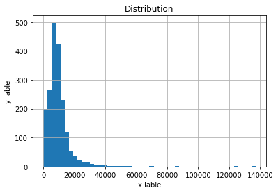

```python
murders['OtherPerCap'].hist(bins=50)
plt.title('Distribution')
plt.xlabel('x lable')
plt.ylabel('y lable')
plt.show()
```

```python
#Check the minimum and maximum value
print(murders['OtherPerCap'].min())
print(murders['OtherPerCap'].max())

#Determine bins based on quantiles
OtherPerCap_ = pd.qcut(murders['OtherPerCap'], q=4)
#Check the value counts of each bin to ensure they are balanced
OtherPerCap_.value_counts()

#Create bin labels
OtherPerCap_labels = ['0-5500', '5500-8000', '8000-11500', '11500-137000']
#Create bins
OtherPerCap_bin = [-1, 5500, 8000, 11500, 137000]
#Add new category
murders['OtherPerCap_bins'] = pd.cut(murders['OtherPerCap'], bins=OtherPerCap_bin, labels=OtherPerCap_labels)
murders.head()
```

```
0.0
137000.0
```

|  | communityname | state | population | householdsize | racepctblack | racePctWhite | racePctAsian | racePctHisp | agePct12t21 | agePct65up | pctUrban | medIncome | pctWFarmSelf | pctWInvInc | pctWPubAsst | pctWRetire | blackPerCap | indianPerCap | AsianPerCap | OtherPerCap | HispPerCap | PctPopUnderPov | PctLess9thGrade | PctBSorMore | PctEmplManu | PctEmplProfServ | PctOccupManu | MalePctDivorce | MalePctNevMarr | … |
| --- | --- | --- | --- | --- | --- | --- | --- | --- | --- | --- | --- | --- | --- | --- | --- | --- | --- | --- | --- | --- | --- | --- | --- | --- | --- | --- | --- | --- | --- | --- |
| 0 | BerkeleyHeightstownship | NJ | 11980 | 3.10 | 1.37 | 91.78 | 6.50 | 1.88 | 12.47 | 11.33 | 100.0 | 75122 | 1.55 | 70.20 | 1.03 | 18.39 | 13600 | 5725 | 27101 | 5115.0 | 22838 | 1.96 | 5.81 | 48.18 | 14.65 | 28.82 | 5.49 | 3.67 | 26.38 | … |
| 1 | Marpletownship | PA | 23123 | 2.82 | 0.80 | 95.57 | 3.44 | 0.85 | 11.01 | 17.18 | 100.0 | 47917 | 1.11 | 64.11 | 2.75 | 22.85 | 18137 | 0 | 20074 | 5250.0 | 12222 | 3.98 | 5.61 | 29.89 | 12.26 | 29.28 | 6.39 | 4.23 | 27.99 | … |
| 2 | Tigardcity | OR | 29344 | 2.43 | 0.74 | 94.33 | 3.43 | 2.35 | 11.36 | 10.28 | 100.0 | 35669 | 1.15 | 55.73 | 2.94 | 14.56 | 16644 | 21606 | 15528 | 5954.0 | 8405 | 4.75 | 2.80 | 30.13 | 15.95 | 21.52 | 8.79 | 10.10 | 25.78 | … |
| 4 | Springfieldcity | MO | 140494 | 2.45 | 2.51 | 95.65 | 0.90 | 0.95 | 18.09 | 13.26 | 100.0 | 21577 | 1.00 | 41.15 | 7.12 | 14.09 | 7382 | 10264 | 10753 | 7192.0 | 8104 | 17.78 | 8.76 | 20.66 | 14.31 | 26.83 | 14.72 | 11.40 | 33.32 | … |
| 5 | Norwoodtown | MA | 28700 | 2.60 | 1.60 | 96.57 | 1.47 | 1.10 | 11.17 | 14.42 | 100.0 | 42805 | 0.39 | 47.70 | 5.41 | 17.23 | 17342 | 21482 | 12639 | 21852.0 | 22594 | 4.01 | 4.49 | 27.01 | 14.02 | 27.17 | 8.50 | 5.97 | 36.05 | … |

```python
murders['OtherPerCap_bins'].value_counts()
```

```
8000-11500      531
11500-137000    472
0-5500          469
5500-8000       447
Name: OtherPerCap_bins, dtype: int64
```

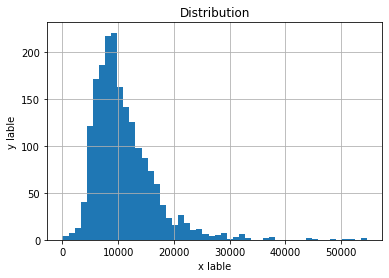

```python
murders['HispPerCap'].hist(bins=50)
plt.title('Distribution')
plt.xlabel('x lable')
plt.ylabel('y lable')
plt.show()
```

```python
#Check the minimum and maximum value
print(murders['HispPerCap'].min())
print(murders['HispPerCap'].max())

#Determine bins based on quantiles
HispPerCap_ = pd.qcut(murders['HispPerCap'], q=4)
#Check the value counts of each bin to ensure they are balanced
HispPerCap_.value_counts()

#Create bin labels
HispPerCap_labels = ['0-7500', '7500-1000', '1000-13500', '13500-55000']
#Create bins
HispPerCap_bin = [-1, 7500, 10000, 13500, 55000]
#Add new category
murders['HispPerCap_bins'] = pd.cut(murders['HispPerCap'], bins=HispPerCap_bin, labels=HispPerCap_labels)
murders.head()
```

```
0
54648
```

|  | communityname | state | population | householdsize | racepctblack | racePctWhite | racePctAsian | racePctHisp | agePct12t21 | agePct65up | pctUrban | medIncome | pctWFarmSelf | pctWInvInc | pctWPubAsst | pctWRetire | blackPerCap | indianPerCap | AsianPerCap | OtherPerCap | HispPerCap | PctPopUnderPov | PctLess9thGrade | PctBSorMore | PctEmplManu | PctEmplProfServ | PctOccupManu | MalePctDivorce | MalePctNevMarr | … |
| --- | --- | --- | --- | --- | --- | --- | --- | --- | --- | --- | --- | --- | --- | --- | --- | --- | --- | --- | --- | --- | --- | --- | --- | --- | --- | --- | --- | --- | --- | --- |
| 0 | BerkeleyHeightstownship | NJ | 11980 | 3.10 | 1.37 | 91.78 | 6.50 | 1.88 | 12.47 | 11.33 | 100.0 | 75122 | 1.55 | 70.20 | 1.03 | 18.39 | 13600 | 5725 | 27101 | 5115.0 | 22838 | 1.96 | 5.81 | 48.18 | 14.65 | 28.82 | 5.49 | 3.67 | 26.38 | … |
| 1 | Marpletownship | PA | 23123 | 2.82 | 0.80 | 95.57 | 3.44 | 0.85 | 11.01 | 17.18 | 100.0 | 47917 | 1.11 | 64.11 | 2.75 | 22.85 | 18137 | 0 | 20074 | 5250.0 | 12222 | 3.98 | 5.61 | 29.89 | 12.26 | 29.28 | 6.39 | 4.23 | 27.99 | … |
| 2 | Tigardcity | OR | 29344 | 2.43 | 0.74 | 94.33 | 3.43 | 2.35 | 11.36 | 10.28 | 100.0 | 35669 | 1.15 | 55.73 | 2.94 | 14.56 | 16644 | 21606 | 15528 | 5954.0 | 8405 | 4.75 | 2.80 | 30.13 | 15.95 | 21.52 | 8.79 | 10.10 | 25.78 | … |
| 4 | Springfieldcity | MO | 140494 | 2.45 | 2.51 | 95.65 | 0.90 | 0.95 | 18.09 | 13.26 | 100.0 | 21577 | 1.00 | 41.15 | 7.12 | 14.09 | 7382 | 10264 | 10753 | 7192.0 | 8104 | 17.78 | 8.76 | 20.66 | 14.31 | 26.83 | 14.72 | 11.40 | 33.32 | … |
| 5 | Norwoodtown | MA | 28700 | 2.60 | 1.60 | 96.57 | 1.47 | 1.10 | 11.17 | 14.42 | 100.0 | 42805 | 0.39 | 47.70 | 5.41 | 17.23 | 17342 | 21482 | 12639 | 21852.0 | 22594 | 4.01 | 4.49 | 27.01 | 14.02 | 27.17 | 8.50 | 5.97 | 36.05 | … |

```python
murders['HispPerCap_bins'].value_counts()
```

```
0-7500         522
7500-1000      487
13500-55000    469
1000-13500     441
Name: HispPerCap_bins, dtype: int64
```

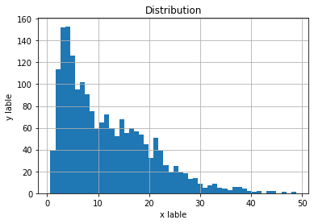

```python
murders['PctPopUnderPov'].hist(bins=50)
plt.title('Distribution')
plt.xlabel('x lable')
plt.ylabel('y lable')
plt.show()
```

```python
#Check the minimum and maximum value
print(murders['PctPopUnderPov'].min())
print(murders['PctPopUnderPov'].max())

#Determine bins based on quantiles
PctPopUnderPov_ = pd.qcut(murders['PctPopUnderPov'], q=4)
#Check the value counts of each bin to ensure they are balanced
PctPopUnderPov_.value_counts()

#Create bin labels
PctPopUnderPov_labels = ['0-5%', '5-10%', '10-17%', '17-60%']
#Create bins
PctPopUnderPov_bin = [0, 5, 10, 17, 60]
#Add new category
murders['PctPopUnderPov_bins'] = pd.cut(murders['PctPopUnderPov'], bins=PctPopUnderPov_bin, labels=PctPopUnderPov_labels)
murders.head()
```

```
0.64
48.82
```

|  | communityname | state | population | householdsize | racepctblack | racePctWhite | racePctAsian | racePctHisp | agePct12t21 | agePct65up | pctUrban | medIncome | pctWFarmSelf | pctWInvInc | pctWPubAsst | pctWRetire | blackPerCap | indianPerCap | AsianPerCap | OtherPerCap | HispPerCap | PctPopUnderPov | PctLess9thGrade | PctBSorMore | PctEmplManu | PctEmplProfServ | PctOccupManu | MalePctDivorce | MalePctNevMarr | … |
| --- | --- | --- | --- | --- | --- | --- | --- | --- | --- | --- | --- | --- | --- | --- | --- | --- | --- | --- | --- | --- | --- | --- | --- | --- | --- | --- | --- | --- | --- | --- |
| 0 | BerkeleyHeightstownship | NJ | 11980 | 3.10 | 1.37 | 91.78 | 6.50 | 1.88 | 12.47 | 11.33 | 100.0 | 75122 | 1.55 | 70.20 | 1.03 | 18.39 | 13600 | 5725 | 27101 | 5115.0 | 22838 | 1.96 | 5.81 | 48.18 | 14.65 | 28.82 | 5.49 | 3.67 | 26.38 | … |
| 1 | Marpletownship | PA | 23123 | 2.82 | 0.80 | 95.57 | 3.44 | 0.85 | 11.01 | 17.18 | 100.0 | 47917 | 1.11 | 64.11 | 2.75 | 22.85 | 18137 | 0 | 20074 | 5250.0 | 12222 | 3.98 | 5.61 | 29.89 | 12.26 | 29.28 | 6.39 | 4.23 | 27.99 | … |
| 2 | Tigardcity | OR | 29344 | 2.43 | 0.74 | 94.33 | 3.43 | 2.35 | 11.36 | 10.28 | 100.0 | 35669 | 1.15 | 55.73 | 2.94 | 14.56 | 16644 | 21606 | 15528 | 5954.0 | 8405 | 4.75 | 2.80 | 30.13 | 15.95 | 21.52 | 8.79 | 10.10 | 25.78 | … |
| 4 | Springfieldcity | MO | 140494 | 2.45 | 2.51 | 95.65 | 0.90 | 0.95 | 18.09 | 13.26 | 100.0 | 21577 | 1.00 | 41.15 | 7.12 | 14.09 | 7382 | 10264 | 10753 | 7192.0 | 8104 | 17.78 | 8.76 | 20.66 | 14.31 | 26.83 | 14.72 | 11.40 | 33.32 | … |
| 5 | Norwoodtown | MA | 28700 | 2.60 | 1.60 | 96.57 | 1.47 | 1.10 | 11.17 | 14.42 | 100.0 | 42805 | 0.39 | 47.70 | 5.41 | 17.23 | 17342 | 21482 | 12639 | 21852.0 | 22594 | 4.01 | 4.49 | 27.01 | 14.02 | 27.17 | 8.50 | 5.97 | 36.05 | … |

```python
murders['PctPopUnderPov_bins'].value_counts()
```

```
0-5%      522
17-60%    483
5-10%     477
10-17%    437
Name: PctPopUnderPov_bins, dtype: int64
```

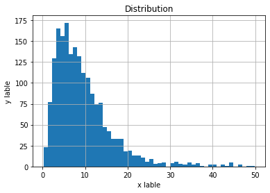

```python
murders['PctLess9thGrade'].hist(bins=50)
plt.title('Distribution')
plt.xlabel('x lable')
plt.ylabel('y lable')
plt.show()
```

```python
#Check the minimum and maximum value
print(murders['PctLess9thGrade'].min())
print(murders['PctLess9thGrade'].max())

#Determine bins based on quantiles
PctLess9thGrade_ = pd.qcut(murders['PctLess9thGrade'], q=4)
#Check the value counts of each bin to ensure they are balanced
PctLess9thGrade_.value_counts()

#Create bin labels
PctLess9thGrade_labels = ['0-5%', '5-8%', '8-12%', '12-50%']
#Create bins
PctLess9thGrade_bin = [0, 5, 8, 12, 50]
#Add new category
murders['PctLess9thGrade_bins'] = pd.cut(murders['PctLess9thGrade'], bins=PctLess9thGrade_bin, labels=PctLess9thGrade_labels)
murders.head()
```

```
0.2
49.89
```

|  | communityname | state | population | householdsize | racepctblack | racePctWhite | racePctAsian | racePctHisp | agePct12t21 | agePct65up | pctUrban | medIncome | pctWFarmSelf | pctWInvInc | pctWPubAsst | pctWRetire | blackPerCap | indianPerCap | AsianPerCap | OtherPerCap | HispPerCap | PctPopUnderPov | PctLess9thGrade | PctBSorMore | PctEmplManu | PctEmplProfServ | PctOccupManu | MalePctDivorce | MalePctNevMarr | … |
| --- | --- | --- | --- | --- | --- | --- | --- | --- | --- | --- | --- | --- | --- | --- | --- | --- | --- | --- | --- | --- | --- | --- | --- | --- | --- | --- | --- | --- | --- | --- |
| 0 | BerkeleyHeightstownship | NJ | 11980 | 3.10 | 1.37 | 91.78 | 6.50 | 1.88 | 12.47 | 11.33 | 100.0 | 75122 | 1.55 | 70.20 | 1.03 | 18.39 | 13600 | 5725 | 27101 | 5115.0 | 22838 | 1.96 | 5.81 | 48.18 | 14.65 | 28.82 | 5.49 | 3.67 | 26.38 | … |
| 1 | Marpletownship | PA | 23123 | 2.82 | 0.80 | 95.57 | 3.44 | 0.85 | 11.01 | 17.18 | 100.0 | 47917 | 1.11 | 64.11 | 2.75 | 22.85 | 18137 | 0 | 20074 | 5250.0 | 12222 | 3.98 | 5.61 | 29.89 | 12.26 | 29.28 | 6.39 | 4.23 | 27.99 | … |
| 2 | Tigardcity | OR | 29344 | 2.43 | 0.74 | 94.33 | 3.43 | 2.35 | 11.36 | 10.28 | 100.0 | 35669 | 1.15 | 55.73 | 2.94 | 14.56 | 16644 | 21606 | 15528 | 5954.0 | 8405 | 4.75 | 2.80 | 30.13 | 15.95 | 21.52 | 8.79 | 10.10 | 25.78 | … |
| 4 | Springfieldcity | MO | 140494 | 2.45 | 2.51 | 95.65 | 0.90 | 0.95 | 18.09 | 13.26 | 100.0 | 21577 | 1.00 | 41.15 | 7.12 | 14.09 | 7382 | 10264 | 10753 | 7192.0 | 8104 | 17.78 | 8.76 | 20.66 | 14.31 | 26.83 | 14.72 | 11.40 | 33.32 | … |
| 5 | Norwoodtown | MA | 28700 | 2.60 | 1.60 | 96.57 | 1.47 | 1.10 | 11.17 | 14.42 | 100.0 | 42805 | 0.39 | 47.70 | 5.41 | 17.23 | 17342 | 21482 | 12639 | 21852.0 | 22594 | 4.01 | 4.49 | 27.01 | 14.02 | 27.17 | 8.50 | 5.97 | 36.05 | … |

```python
murders['PctLess9thGrade_bins'].value_counts()
```

```
0-5%      516
12-50%    488
5-8%      462
8-12%     453
Name: PctLess9thGrade_bins, dtype: int64
```

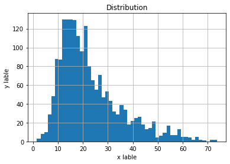

```python
murders['PctBSorMore'].hist(bins=50)
plt.title('Distribution')
plt.xlabel('x lable')
plt.ylabel('y lable')
plt.show()
```

```python
#Check the minimum and maximum value
print(murders['PctBSorMore'].min())
print(murders['PctBSorMore'].max())

#Determine bins based on quantiles
PctBSorMore_ = pd.qcut(murders['PctBSorMore'], q=4)
#Check the value counts of each bin to ensure they are balanced
PctBSorMore_.value_counts()

#Create bin labels
PctBSorMore_labels = ['0-14', '14-19', '19-30', '30-80']
#Create bins
PctBSorMore_bin = [0, 14, 19, 30, 80]
#Add new category
murders['PctBSorMore_bins'] = pd.cut(murders['PctBSorMore'], bins=PctBSorMore_bin, labels=PctBSorMore_labels)
murders.head()
```

```
1.63
73.63
```

|  | communityname | state | population | householdsize | racepctblack | racePctWhite | racePctAsian | racePctHisp | agePct12t21 | agePct65up | pctUrban | medIncome | pctWFarmSelf | pctWInvInc | pctWPubAsst | pctWRetire | blackPerCap | indianPerCap | AsianPerCap | OtherPerCap | HispPerCap | PctPopUnderPov | PctLess9thGrade | PctBSorMore | PctEmplManu | PctEmplProfServ | PctOccupManu | MalePctDivorce | MalePctNevMarr | … |
| --- | --- | --- | --- | --- | --- | --- | --- | --- | --- | --- | --- | --- | --- | --- | --- | --- | --- | --- | --- | --- | --- | --- | --- | --- | --- | --- | --- | --- | --- | --- |
| 0 | BerkeleyHeightstownship | NJ | 11980 | 3.10 | 1.37 | 91.78 | 6.50 | 1.88 | 12.47 | 11.33 | 100.0 | 75122 | 1.55 | 70.20 | 1.03 | 18.39 | 13600 | 5725 | 27101 | 5115.0 | 22838 | 1.96 | 5.81 | 48.18 | 14.65 | 28.82 | 5.49 | 3.67 | 26.38 | … |
| 1 | Marpletownship | PA | 23123 | 2.82 | 0.80 | 95.57 | 3.44 | 0.85 | 11.01 | 17.18 | 100.0 | 47917 | 1.11 | 64.11 | 2.75 | 22.85 | 18137 | 0 | 20074 | 5250.0 | 12222 | 3.98 | 5.61 | 29.89 | 12.26 | 29.28 | 6.39 | 4.23 | 27.99 | … |
| 2 | Tigardcity | OR | 29344 | 2.43 | 0.74 | 94.33 | 3.43 | 2.35 | 11.36 | 10.28 | 100.0 | 35669 | 1.15 | 55.73 | 2.94 | 14.56 | 16644 | 21606 | 15528 | 5954.0 | 8405 | 4.75 | 2.80 | 30.13 | 15.95 | 21.52 | 8.79 | 10.10 | 25.78 | … |
| 4 | Springfieldcity | MO | 140494 | 2.45 | 2.51 | 95.65 | 0.90 | 0.95 | 18.09 | 13.26 | 100.0 | 21577 | 1.00 | 41.15 | 7.12 | 14.09 | 7382 | 10264 | 10753 | 7192.0 | 8104 | 17.78 | 8.76 | 20.66 | 14.31 | 26.83 | 14.72 | 11.40 | 33.32 | … |
| 5 | Norwoodtown | MA | 28700 | 2.60 | 1.60 | 96.57 | 1.47 | 1.10 | 11.17 | 14.42 | 100.0 | 42805 | 0.39 | 47.70 | 5.41 | 17.23 | 17342 | 21482 | 12639 | 21852.0 | 22594 | 4.01 | 4.49 | 27.01 | 14.02 | 27.17 | 8.50 | 5.97 | 36.05 | … |

```python
murders['PctBSorMore_bins'].value_counts()
```

```
19-30    565
0-14     473
14-19    443
30-80    438
Name: PctBSorMore_bins, dtype: int64
```

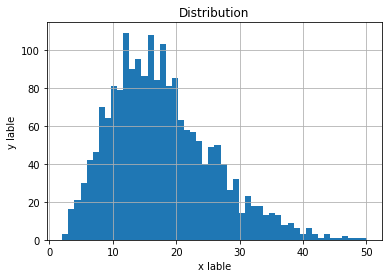

```python
murders['PctEmplManu'].hist(bins=50)
plt.title('Distribution')
plt.xlabel('x lable')
plt.ylabel('y lable')
plt.show()
```

```python
# apply normalization technique, using a range of [0,1]
murders['PctEmplManu_norm'] = (murders['PctEmplManu'] - murders['PctEmplManu'].min()) / (murders['PctEmplManu'].max() - murders['PctEmplManu'].min())

murders.head()
```

|  | communityname | state | population | householdsize | racepctblack | racePctWhite | racePctAsian | racePctHisp | agePct12t21 | agePct65up | pctUrban | medIncome | pctWFarmSelf | pctWInvInc | pctWPubAsst | pctWRetire | blackPerCap | indianPerCap | AsianPerCap | OtherPerCap | HispPerCap | PctPopUnderPov | PctLess9thGrade | PctBSorMore | PctEmplManu | PctEmplProfServ | PctOccupManu | MalePctDivorce | MalePctNevMarr | … |
| --- | --- | --- | --- | --- | --- | --- | --- | --- | --- | --- | --- | --- | --- | --- | --- | --- | --- | --- | --- | --- | --- | --- | --- | --- | --- | --- | --- | --- | --- | --- |
| 0 | BerkeleyHeightstownship | NJ | 11980 | 3.10 | 1.37 | 91.78 | 6.50 | 1.88 | 12.47 | 11.33 | 100.0 | 75122 | 1.55 | 70.20 | 1.03 | 18.39 | 13600 | 5725 | 27101 | 5115.0 | 22838 | 1.96 | 5.81 | 48.18 | 14.65 | 28.82 | 5.49 | 3.67 | 26.38 | … |
| 1 | Marpletownship | PA | 23123 | 2.82 | 0.80 | 95.57 | 3.44 | 0.85 | 11.01 | 17.18 | 100.0 | 47917 | 1.11 | 64.11 | 2.75 | 22.85 | 18137 | 0 | 20074 | 5250.0 | 12222 | 3.98 | 5.61 | 29.89 | 12.26 | 29.28 | 6.39 | 4.23 | 27.99 | … |
| 2 | Tigardcity | OR | 29344 | 2.43 | 0.74 | 94.33 | 3.43 | 2.35 | 11.36 | 10.28 | 100.0 | 35669 | 1.15 | 55.73 | 2.94 | 14.56 | 16644 | 21606 | 15528 | 5954.0 | 8405 | 4.75 | 2.80 | 30.13 | 15.95 | 21.52 | 8.79 | 10.10 | 25.78 | … |
| 4 | Springfieldcity | MO | 140494 | 2.45 | 2.51 | 95.65 | 0.90 | 0.95 | 18.09 | 13.26 | 100.0 | 21577 | 1.00 | 41.15 | 7.12 | 14.09 | 7382 | 10264 | 10753 | 7192.0 | 8104 | 17.78 | 8.76 | 20.66 | 14.31 | 26.83 | 14.72 | 11.40 | 33.32 | … |
| 5 | Norwoodtown | MA | 28700 | 2.60 | 1.60 | 96.57 | 1.47 | 1.10 | 11.17 | 14.42 | 100.0 | 42805 | 0.39 | 47.70 | 5.41 | 17.23 | 17342 | 21482 | 12639 | 21852.0 | 22594 | 4.01 | 4.49 | 27.01 | 14.02 | 27.17 | 8.50 | 5.97 | 36.05 | … |

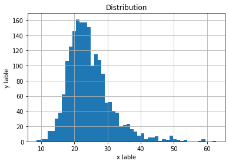

```python
murders['PctEmplProfServ'].hist(bins=50)
plt.title('Distribution')
plt.xlabel('x lable')
plt.ylabel('y lable')
plt.show()
```

```python
# apply normalization technique, using a range of [0,1]
murders['PctEmplProfServ_norm'] = (murders['PctEmplProfServ'] - murders['PctEmplProfServ'].min()) / (murders['PctEmplProfServ'].max() - murders['PctEmplProfServ'].min())

murders.head()
```

|  | communityname | state | population | householdsize | racepctblack | racePctWhite | racePctAsian | racePctHisp | agePct12t21 | agePct65up | pctUrban | medIncome | pctWFarmSelf | pctWInvInc | pctWPubAsst | pctWRetire | blackPerCap | indianPerCap | AsianPerCap | OtherPerCap | HispPerCap | PctPopUnderPov | PctLess9thGrade | PctBSorMore | PctEmplManu | PctEmplProfServ | PctOccupManu | MalePctDivorce | MalePctNevMarr | … |
| --- | --- | --- | --- | --- | --- | --- | --- | --- | --- | --- | --- | --- | --- | --- | --- | --- | --- | --- | --- | --- | --- | --- | --- | --- | --- | --- | --- | --- | --- | --- |
| 0 | BerkeleyHeightstownship | NJ | 11980 | 3.10 | 1.37 | 91.78 | 6.50 | 1.88 | 12.47 | 11.33 | 100.0 | 75122 | 1.55 | 70.20 | 1.03 | 18.39 | 13600 | 5725 | 27101 | 5115.0 | 22838 | 1.96 | 5.81 | 48.18 | 14.65 | 28.82 | 5.49 | 3.67 | 26.38 | … |
| 1 | Marpletownship | PA | 23123 | 2.82 | 0.80 | 95.57 | 3.44 | 0.85 | 11.01 | 17.18 | 100.0 | 47917 | 1.11 | 64.11 | 2.75 | 22.85 | 18137 | 0 | 20074 | 5250.0 | 12222 | 3.98 | 5.61 | 29.89 | 12.26 | 29.28 | 6.39 | 4.23 | 27.99 | … |
| 2 | Tigardcity | OR | 29344 | 2.43 | 0.74 | 94.33 | 3.43 | 2.35 | 11.36 | 10.28 | 100.0 | 35669 | 1.15 | 55.73 | 2.94 | 14.56 | 16644 | 21606 | 15528 | 5954.0 | 8405 | 4.75 | 2.80 | 30.13 | 15.95 | 21.52 | 8.79 | 10.10 | 25.78 | … |
| 4 | Springfieldcity | MO | 140494 | 2.45 | 2.51 | 95.65 | 0.90 | 0.95 | 18.09 | 13.26 | 100.0 | 21577 | 1.00 | 41.15 | 7.12 | 14.09 | 7382 | 10264 | 10753 | 7192.0 | 8104 | 17.78 | 8.76 | 20.66 | 14.31 | 26.83 | 14.72 | 11.40 | 33.32 | … |
| 5 | Norwoodtown | MA | 28700 | 2.60 | 1.60 | 96.57 | 1.47 | 1.10 | 11.17 | 14.42 | 100.0 | 42805 | 0.39 | 47.70 | 5.41 | 17.23 | 17342 | 21482 | 12639 | 21852.0 | 22594 | 4.01 | 4.49 | 27.01 | 14.02 | 27.17 | 8.50 | 5.97 | 36.05 | … |

```python
murders = murders.drop(['PctEmplProfServ_bins'], axis=1)
```

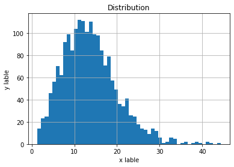

```python
murders['PctOccupManu'].hist(bins=50)
plt.title('Distribution')
plt.xlabel('x lable')
plt.ylabel('y lable')
plt.show()
```

```python
# apply normalization technique, using a range of [0,1]
murders['PctOccupManu_norm'] = (murders['PctOccupManu'] - murders['PctOccupManu'].min()) / (murders['PctOccupManu'].max() - murders['PctOccupManu'].min())

murders.head()
```

|  | communityname | state | population | householdsize | racepctblack | racePctWhite | racePctAsian | racePctHisp | agePct12t21 | agePct65up | pctUrban | medIncome | pctWFarmSelf | pctWInvInc | pctWPubAsst | pctWRetire | blackPerCap | indianPerCap | AsianPerCap | OtherPerCap | HispPerCap | PctPopUnderPov | PctLess9thGrade | PctBSorMore | PctEmplManu | PctEmplProfServ | PctOccupManu | MalePctDivorce | MalePctNevMarr | … |
| --- | --- | --- | --- | --- | --- | --- | --- | --- | --- | --- | --- | --- | --- | --- | --- | --- | --- | --- | --- | --- | --- | --- | --- | --- | --- | --- | --- | --- | --- | --- |
| 0 | BerkeleyHeightstownship | NJ | 11980 | 3.10 | 1.37 | 91.78 | 6.50 | 1.88 | 12.47 | 11.33 | 100.0 | 75122 | 1.55 | 70.20 | 1.03 | 18.39 | 13600 | 5725 | 27101 | 5115.0 | 22838 | 1.96 | 5.81 | 48.18 | 14.65 | 28.82 | 5.49 | 3.67 | 26.38 | … |
| 1 | Marpletownship | PA | 23123 | 2.82 | 0.80 | 95.57 | 3.44 | 0.85 | 11.01 | 17.18 | 100.0 | 47917 | 1.11 | 64.11 | 2.75 | 22.85 | 18137 | 0 | 20074 | 5250.0 | 12222 | 3.98 | 5.61 | 29.89 | 12.26 | 29.28 | 6.39 | 4.23 | 27.99 | … |
| 2 | Tigardcity | OR | 29344 | 2.43 | 0.74 | 94.33 | 3.43 | 2.35 | 11.36 | 10.28 | 100.0 | 35669 | 1.15 | 55.73 | 2.94 | 14.56 | 16644 | 21606 | 15528 | 5954.0 | 8405 | 4.75 | 2.80 | 30.13 | 15.95 | 21.52 | 8.79 | 10.10 | 25.78 | … |
| 4 | Springfieldcity | MO | 140494 | 2.45 | 2.51 | 95.65 | 0.90 | 0.95 | 18.09 | 13.26 | 100.0 | 21577 | 1.00 | 41.15 | 7.12 | 14.09 | 7382 | 10264 | 10753 | 7192.0 | 8104 | 17.78 | 8.76 | 20.66 | 14.31 | 26.83 | 14.72 | 11.40 | 33.32 | … |
| 5 | Norwoodtown | MA | 28700 | 2.60 | 1.60 | 96.57 | 1.47 | 1.10 | 11.17 | 14.42 | 100.0 | 42805 | 0.39 | 47.70 | 5.41 | 17.23 | 17342 | 21482 | 12639 | 21852.0 | 22594 | 4.01 | 4.49 | 27.01 | 14.02 | 27.17 | 8.50 | 5.97 | 36.05 | … |

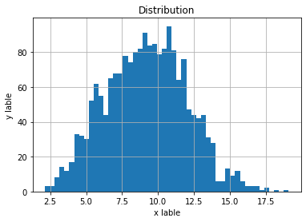

```python
murders['MalePctDivorce'].hist(bins=50)
plt.title('Distribution')
plt.xlabel('x lable')
plt.ylabel('y lable')
plt.show()
```

```python
# apply normalization technique, using a range of [0,1]
murders['MalePctDivorce_norm'] = (murders['MalePctDivorce'] - murders['MalePctDivorce'].min()) / (murders['MalePctDivorce'].max() - murders['MalePctDivorce'].min())

murders.head()
```

|  | communityname | state | population | householdsize | racepctblack | racePctWhite | racePctAsian | racePctHisp | agePct12t21 | agePct65up | pctUrban | medIncome | pctWFarmSelf | pctWInvInc | pctWPubAsst | pctWRetire | blackPerCap | indianPerCap | AsianPerCap | OtherPerCap | HispPerCap | PctPopUnderPov | PctLess9thGrade | PctBSorMore | PctEmplManu | PctEmplProfServ | PctOccupManu | MalePctDivorce | MalePctNevMarr | … |
| --- | --- | --- | --- | --- | --- | --- | --- | --- | --- | --- | --- | --- | --- | --- | --- | --- | --- | --- | --- | --- | --- | --- | --- | --- | --- | --- | --- | --- | --- | --- |
| 0 | BerkeleyHeightstownship | NJ | 11980 | 3.10 | 1.37 | 91.78 | 6.50 | 1.88 | 12.47 | 11.33 | 100.0 | 75122 | 1.55 | 70.20 | 1.03 | 18.39 | 13600 | 5725 | 27101 | 5115.0 | 22838 | 1.96 | 5.81 | 48.18 | 14.65 | 28.82 | 5.49 | 3.67 | 26.38 | … |
| 1 | Marpletownship | PA | 23123 | 2.82 | 0.80 | 95.57 | 3.44 | 0.85 | 11.01 | 17.18 | 100.0 | 47917 | 1.11 | 64.11 | 2.75 | 22.85 | 18137 | 0 | 20074 | 5250.0 | 12222 | 3.98 | 5.61 | 29.89 | 12.26 | 29.28 | 6.39 | 4.23 | 27.99 | … |
| 2 | Tigardcity | OR | 29344 | 2.43 | 0.74 | 94.33 | 3.43 | 2.35 | 11.36 | 10.28 | 100.0 | 35669 | 1.15 | 55.73 | 2.94 | 14.56 | 16644 | 21606 | 15528 | 5954.0 | 8405 | 4.75 | 2.80 | 30.13 | 15.95 | 21.52 | 8.79 | 10.10 | 25.78 | … |
| 4 | Springfieldcity | MO | 140494 | 2.45 | 2.51 | 95.65 | 0.90 | 0.95 | 18.09 | 13.26 | 100.0 | 21577 | 1.00 | 41.15 | 7.12 | 14.09 | 7382 | 10264 | 10753 | 7192.0 | 8104 | 17.78 | 8.76 | 20.66 | 14.31 | 26.83 | 14.72 | 11.40 | 33.32 | … |
| 5 | Norwoodtown | MA | 28700 | 2.60 | 1.60 | 96.57 | 1.47 | 1.10 | 11.17 | 14.42 | 100.0 | 42805 | 0.39 | 47.70 | 5.41 | 17.23 | 17342 | 21482 | 12639 | 21852.0 | 22594 | 4.01 | 4.49 | 27.01 | 14.02 | 27.17 | 8.50 | 5.97 | 36.05 | … |

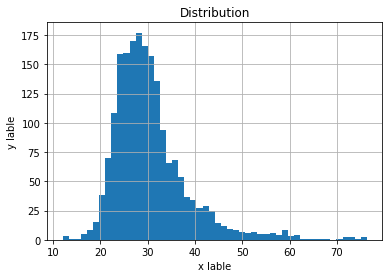

```python
murders['MalePctNevMarr'].hist(bins=50)
plt.title('Distribution')
plt.xlabel('x lable')
plt.ylabel('y lable')
plt.show()
```

```python
# apply normalization technique, using a range of [0,1]
murders['MalePctNevMarr_norm'] = (murders['MalePctNevMarr'] - murders['MalePctNevMarr'].min()) / (murders['MalePctNevMarr'].max() - murders['MalePctNevMarr'].min())

murders.head()
```

|  | communityname | state | population | householdsize | racepctblack | racePctWhite | racePctAsian | racePctHisp | agePct12t21 | agePct65up | pctUrban | medIncome | pctWFarmSelf | pctWInvInc | pctWPubAsst | pctWRetire | blackPerCap | indianPerCap | AsianPerCap | OtherPerCap | HispPerCap | PctPopUnderPov | PctLess9thGrade | PctBSorMore | PctEmplManu | PctEmplProfServ | PctOccupManu | MalePctDivorce | MalePctNevMarr | … |
| --- | --- | --- | --- | --- | --- | --- | --- | --- | --- | --- | --- | --- | --- | --- | --- | --- | --- | --- | --- | --- | --- | --- | --- | --- | --- | --- | --- | --- | --- | --- |
| 0 | BerkeleyHeightstownship | NJ | 11980 | 3.10 | 1.37 | 91.78 | 6.50 | 1.88 | 12.47 | 11.33 | 100.0 | 75122 | 1.55 | 70.20 | 1.03 | 18.39 | 13600 | 5725 | 27101 | 5115.0 | 22838 | 1.96 | 5.81 | 48.18 | 14.65 | 28.82 | 5.49 | 3.67 | 26.38 | … |
| 1 | Marpletownship | PA | 23123 | 2.82 | 0.80 | 95.57 | 3.44 | 0.85 | 11.01 | 17.18 | 100.0 | 47917 | 1.11 | 64.11 | 2.75 | 22.85 | 18137 | 0 | 20074 | 5250.0 | 12222 | 3.98 | 5.61 | 29.89 | 12.26 | 29.28 | 6.39 | 4.23 | 27.99 | … |
| 2 | Tigardcity | OR | 29344 | 2.43 | 0.74 | 94.33 | 3.43 | 2.35 | 11.36 | 10.28 | 100.0 | 35669 | 1.15 | 55.73 | 2.94 | 14.56 | 16644 | 21606 | 15528 | 5954.0 | 8405 | 4.75 | 2.80 | 30.13 | 15.95 | 21.52 | 8.79 | 10.10 | 25.78 | … |
| 4 | Springfieldcity | MO | 140494 | 2.45 | 2.51 | 95.65 | 0.90 | 0.95 | 18.09 | 13.26 | 100.0 | 21577 | 1.00 | 41.15 | 7.12 | 14.09 | 7382 | 10264 | 10753 | 7192.0 | 8104 | 17.78 | 8.76 | 20.66 | 14.31 | 26.83 | 14.72 | 11.40 | 33.32 | … |
| 5 | Norwoodtown | MA | 28700 | 2.60 | 1.60 | 96.57 | 1.47 | 1.10 | 11.17 | 14.42 | 100.0 | 42805 | 0.39 | 47.70 | 5.41 | 17.23 | 17342 | 21482 | 12639 | 21852.0 | 22594 | 4.01 | 4.49 | 27.01 | 14.02 | 27.17 | 8.50 | 5.97 | 36.05 | … |

```python
murders = murders.drop(['MalePctNevMarr_bins'], axis=1)
```

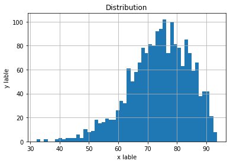

```python
murders['PctFam2Par'].hist(bins=50)
plt.title('Distribution')
plt.xlabel('x lable')
plt.ylabel('y lable')
plt.show()
```

```python
#Check the minimum and maximum value
print(murders['PctFam2Par'].min())
print(murders['PctFam2Par'].max())

#Determine bins based on quantiles
PctFam2Par_ = pd.qcut(murders['PctFam2Par'], q=4)
#Check the value counts of each bin to ensure they are balanced
PctFam2Par_.value_counts()

#Create bin labels
PctFam2Par_labels = ['0-67%', '67-70%', '75-82%', '82-95%']
#Create bins
PctFam2Par_bin = [0, 67, 75, 82, 95]
#Add new category
murders['PctFam2Par_bins'] = pd.cut(murders['PctFam2Par'], bins=PctFam2Par_bin, labels=PctFam2Par_labels)
murders.head()
```

```
32.24
93.6
```

|  | communityname | state | population | householdsize | racepctblack | racePctWhite | racePctAsian | racePctHisp | agePct12t21 | agePct65up | pctUrban | medIncome | pctWFarmSelf | pctWInvInc | pctWPubAsst | pctWRetire | blackPerCap | indianPerCap | AsianPerCap | OtherPerCap | HispPerCap | PctPopUnderPov | PctLess9thGrade | PctBSorMore | PctEmplManu | PctEmplProfServ | PctOccupManu | MalePctDivorce | MalePctNevMarr | … |
| --- | --- | --- | --- | --- | --- | --- | --- | --- | --- | --- | --- | --- | --- | --- | --- | --- | --- | --- | --- | --- | --- | --- | --- | --- | --- | --- | --- | --- | --- | --- |
| 0 | BerkeleyHeightstownship | NJ | 11980 | 3.10 | 1.37 | 91.78 | 6.50 | 1.88 | 12.47 | 11.33 | 100.0 | 75122 | 1.55 | 70.20 | 1.03 | 18.39 | 13600 | 5725 | 27101 | 5115.0 | 22838 | 1.96 | 5.81 | 48.18 | 14.65 | 28.82 | 5.49 | 3.67 | 26.38 | … |
| 1 | Marpletownship | PA | 23123 | 2.82 | 0.80 | 95.57 | 3.44 | 0.85 | 11.01 | 17.18 | 100.0 | 47917 | 1.11 | 64.11 | 2.75 | 22.85 | 18137 | 0 | 20074 | 5250.0 | 12222 | 3.98 | 5.61 | 29.89 | 12.26 | 29.28 | 6.39 | 4.23 | 27.99 | … |
| 2 | Tigardcity | OR | 29344 | 2.43 | 0.74 | 94.33 | 3.43 | 2.35 | 11.36 | 10.28 | 100.0 | 35669 | 1.15 | 55.73 | 2.94 | 14.56 | 16644 | 21606 | 15528 | 5954.0 | 8405 | 4.75 | 2.80 | 30.13 | 15.95 | 21.52 | 8.79 | 10.10 | 25.78 | … |
| 4 | Springfieldcity | MO | 140494 | 2.45 | 2.51 | 95.65 | 0.90 | 0.95 | 18.09 | 13.26 | 100.0 | 21577 | 1.00 | 41.15 | 7.12 | 14.09 | 7382 | 10264 | 10753 | 7192.0 | 8104 | 17.78 | 8.76 | 20.66 | 14.31 | 26.83 | 14.72 | 11.40 | 33.32 | … |
| 5 | Norwoodtown | MA | 28700 | 2.60 | 1.60 | 96.57 | 1.47 | 1.10 | 11.17 | 14.42 | 100.0 | 42805 | 0.39 | 47.70 | 5.41 | 17.23 | 17342 | 21482 | 12639 | 21852.0 | 22594 | 4.01 | 4.49 | 27.01 | 14.02 | 27.17 | 8.50 | 5.97 | 36.05 | … |

```python
murders['PctFam2Par_bins'].value_counts()
```

```
67-70%    533
75-82%    482
82-95%    462
0-67%     442
Name: PctFam2Par_bins, dtype: int64
```

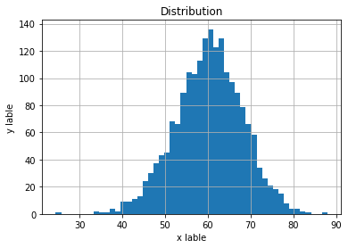

```python
murders['PctWorkMomYoungKids'].hist(bins=50)
plt.title('Distribution')
plt.xlabel('x lable')
plt.ylabel('y lable')
plt.show()
```

```python
# apply normalization technique, using a range of [0,1]
murders['PctWorkMomYoungKids_norm'] = (murders['PctWorkMomYoungKids'] - murders['PctWorkMomYoungKids'].min()) / (murders['PctWorkMomYoungKids'].max() - murders['PctWorkMomYoungKids'].min())

murders.head()
```

|  | communityname | state | population | householdsize | racepctblack | racePctWhite | racePctAsian | racePctHisp | agePct12t21 | agePct65up | pctUrban | medIncome | pctWFarmSelf | pctWInvInc | pctWPubAsst | pctWRetire | blackPerCap | indianPerCap | AsianPerCap | OtherPerCap | HispPerCap | PctPopUnderPov | PctLess9thGrade | PctBSorMore | PctEmplManu | PctEmplProfServ | PctOccupManu | MalePctDivorce | MalePctNevMarr | … |
| --- | --- | --- | --- | --- | --- | --- | --- | --- | --- | --- | --- | --- | --- | --- | --- | --- | --- | --- | --- | --- | --- | --- | --- | --- | --- | --- | --- | --- | --- | --- |
| 0 | BerkeleyHeightstownship | NJ | 11980 | 3.10 | 1.37 | 91.78 | 6.50 | 1.88 | 12.47 | 11.33 | 100.0 | 75122 | 1.55 | 70.20 | 1.03 | 18.39 | 13600 | 5725 | 27101 | 5115.0 | 22838 | 1.96 | 5.81 | 48.18 | 14.65 | 28.82 | 5.49 | 3.67 | 26.38 | … |
| 1 | Marpletownship | PA | 23123 | 2.82 | 0.80 | 95.57 | 3.44 | 0.85 | 11.01 | 17.18 | 100.0 | 47917 | 1.11 | 64.11 | 2.75 | 22.85 | 18137 | 0 | 20074 | 5250.0 | 12222 | 3.98 | 5.61 | 29.89 | 12.26 | 29.28 | 6.39 | 4.23 | 27.99 | … |
| 2 | Tigardcity | OR | 29344 | 2.43 | 0.74 | 94.33 | 3.43 | 2.35 | 11.36 | 10.28 | 100.0 | 35669 | 1.15 | 55.73 | 2.94 | 14.56 | 16644 | 21606 | 15528 | 5954.0 | 8405 | 4.75 | 2.80 | 30.13 | 15.95 | 21.52 | 8.79 | 10.10 | 25.78 | … |
| 4 | Springfieldcity | MO | 140494 | 2.45 | 2.51 | 95.65 | 0.90 | 0.95 | 18.09 | 13.26 | 100.0 | 21577 | 1.00 | 41.15 | 7.12 | 14.09 | 7382 | 10264 | 10753 | 7192.0 | 8104 | 17.78 | 8.76 | 20.66 | 14.31 | 26.83 | 14.72 | 11.40 | 33.32 | … |
| 5 | Norwoodtown | MA | 28700 | 2.60 | 1.60 | 96.57 | 1.47 | 1.10 | 11.17 | 14.42 | 100.0 | 42805 | 0.39 | 47.70 | 5.41 | 17.23 | 17342 | 21482 | 12639 | 21852.0 | 22594 | 4.01 | 4.49 | 27.01 | 14.02 | 27.17 | 8.50 | 5.97 | 36.05 | … |

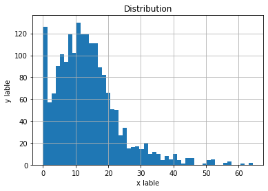

```python
murders['PctImmigRecent'].hist(bins=50)
plt.title('Distribution')
plt.xlabel('x lable')
plt.ylabel('y lable')
plt.show()
```